# Replication of Faber’s A Quantitative Approach to Tactical Asset Allocation - South Africa

#### Analysing asset class returns, max drawdowns and other performance statistics

Using the package performance analytics, common performance statistics such as CAGR, volatility and sharpe ratios can be calculated.

```r
#Create xts for Returns
Returns <- AllAssets.ret[SubsetPeriod.Reporting]
#calculate statistics and store as "stats"
stats <- rbind(100*Return.annualized(Returns,scale = 12),
               100*StdDev.annualized(Returns,scale = 12),
               SharpeRatio.annualized(Returns,Rf = AllAssets.ret$TBILLS),
               100*maxDrawdown(Returns,scale = 12,invert = FALSE),
               100*c(Return.annualized(Returns$CPI,scale = 12)))
#rename table rows/column names and format
colnames(stats) <- symbols
rownames(stats) <- c("Return",
                     "Volatility",
                     paste("Sharpe (",round(stats[1,"TBILLS"],2),"%)", sep = ""),
                     "MaxDD",
                     "Inflation CAGR")
stats <- round(stats[,-7],2) #delete inflation column - change to 7 when including property.
#print
stats
```

```
               TBILLS  SP500   EAFE US10YR   GSCI NAREIT
Return           4.93  10.18   8.75   7.41   5.85   9.65
Volatility       1.00  15.30  17.21   8.33  20.52  17.81
Sharpe (4.93%)   0.00   0.33   0.21   0.28   0.04   0.25
MaxDD            0.00 -50.95 -56.40 -15.75 -80.90 -68.18
Inflation CAGR   4.04   4.04   4.04   4.04   4.04   4.04
```

```r
#copies stats to clipboad for pasting into word/excel
write.table(stats, "clipboard", sep="\t", col.names=NA)
```

#### Managing Risk

Lets chart each asset with its 10 month simple moving average

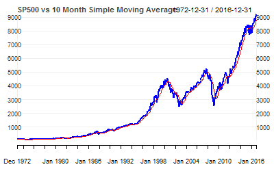

```r
myChart_Theme <- chart_theme() #Create a chart_theme
myChart_Theme$col$line.col <- "blue"
SMAperiod <- 10
chart_Series(Cl(SP500),
  name = paste("SP500 vs 10 Month Simple Moving Average",sep = ""),
  theme=myChart_Theme,
  type = "line",
  subset = SubsetPeriod.Reporting,
  TA = 'add_SMA(n=SMAperiod, on=1, col="red")'
  )
```

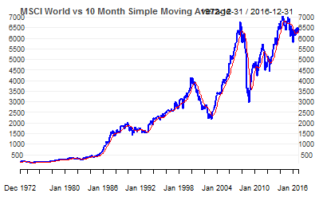

```r
chart_Series(Cl(EAFE),
  name = paste("MSCI World vs 10 Month Simple Moving Average",sep = ""),
  theme=myChart_Theme,
  type = "line",
  subset = SubsetPeriod.Reporting,
  TA = 'add_SMA(n=SMAperiod, on=1, col="red")'
  )
```

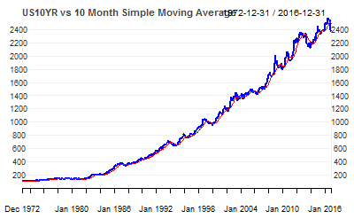

```r
chart_Series(Cl(US10YR),
  name = paste("US10YR vs 10 Month Simple Moving Average",sep = ""),
  theme=myChart_Theme,
  type = "line",
  subset = SubsetPeriod.Reporting,
  TA = 'add_SMA(n=SMAperiod, on=1, col="red")'
  )
```

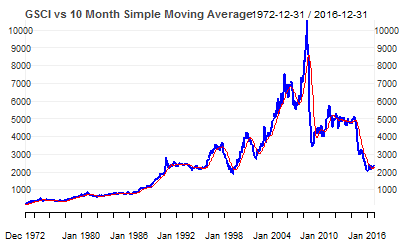

```r
chart_Series(Cl(GSCI),
  name = paste("GSCI vs 10 Month Simple Moving Average",sep = ""),
  theme=myChart_Theme,
  type = "line",
  subset = SubsetPeriod.Reporting,
  TA = 'add_SMA(n=SMAperiod, on=1, col="red")'
  )
```

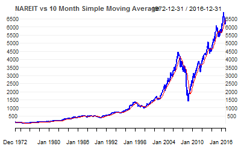

```r
chart_Series(Cl(NAREIT),
  name = paste("NAREIT vs 10 Month Simple Moving Average",sep = ""),
  theme=myChart_Theme,
  type = "line",
  subset = SubsetPeriod.Reporting,
  TA = 'add_SMA(n=SMAperiod, on=1, col="red")'
  )
```

```r
#change to other chart so can make it log?
```

#### Calculating returns

```r
#load an additional library
library(dplyr)
#Create new all assets
AllAssets <- cbind.xts(Cl(SP500),
                       Cl(EAFE),
                       Cl(US10YR),
                       Cl(GSCI),
                       Cl(NAREIT),
                       Cl(TBILLYIELDS))
AllAssets <- AllAssets[SubsetPeriod.Calculations]
#create dataframe - tidyverse not compatible with xts?
AllAssets.df <- data.frame(date=index(AllAssets), coredata(AllAssets)) #, row.names = index(AllAssets))
BuyBand <- 1.025
SellBand <- 1.00
#mutate new columns
AllAssets.df  <- mutate(AllAssets.df,
  "RF.ret" =  c(0,lag((TBILLYIELDS.Close/100)/12)[-1]),
  #is this right?
  "SP500.ret" =  c(0,diff(SP500.Close)/lag(SP500.Close)[-1]),

  "SP500.2m.SMA" =  rollmean(SP500.Close,2,fill = 0,align = "right"),
  "SP500.5m.SMA" =  rollmean(SP500.Close,5,fill = 0,align = "right"),
  "SP500.10m.SMA" =  rollmean(SP500.Close,10,fill = 0,align = "right"),
  "SP500.2m.signal" =  lag(ifelse(SP500.Close>=SP500.2m.SMA,1,0)),
  "SP500.5m.signal" =  lag(ifelse(SP500.Close>=SP500.5m.SMA,1,0)),
  "SP500.10m.signal" =  lag(ifelse(SP500.Close>=SP500.10m.SMA,1,0)),
  "SP500.2m.signal.delayed" =  lag(ifelse(SP500.Close>=SP500.2m.SMA,ifelse(SP500.2m.signal==1,1,0),0)),
  "SP500.5m.signal.delayed" =  lag(ifelse(SP500.Close>=SP500.5m.SMA,ifelse(SP500.5m.signal==1,1,0),0)),
  "SP500.10m.signal.delayed" =  lag(ifelse(SP500.Close>=SP500.10m.SMA,ifelse(SP500.10m.signal==1,1,0),0)),
  "SP500.2m.signal.band" =  ifelse(row_number()<=2,0,
                                    lag(ifelse(SP500.Close>=(BuyBand*SP500.2m.SMA),1,
                                        ifelse(SP500.Close<(SellBand*SP500.2m.SMA),0,2)))),
  "SP500.5m.signal.band" =  ifelse(row_number()<=5,0,
                                    lag(ifelse(SP500.Close>=(BuyBand*SP500.5m.SMA),1,
                                        ifelse(SP500.Close<(SellBand*SP500.5m.SMA),0,2)))),
  "SP500.10m.signal.band" =  ifelse(row_number()<=10,0,
                                    lag(ifelse(SP500.Close>=(BuyBand*SP500.10m.SMA),1,
                                        ifelse(SP500.Close<(SellBand*SP500.10m.SMA),0,2)))),

  "SP500.2m.timingret" = ifelse(SP500.2m.signal == 1,SP500.ret,RF.ret),
  "SP500.5m.timingret" = ifelse(SP500.5m.signal == 1,SP500.ret,RF.ret),
  "SP500.10m.timingret" = ifelse(SP500.10m.signal == 1,SP500.ret,RF.ret),
  "SP500.2m.timingret.delayed" = ifelse(SP500.2m.signal.delayed == 1,SP500.ret,RF.ret),
  "SP500.5m.timingret.delayed" = ifelse(SP500.5m.signal.delayed == 1,SP500.ret,RF.ret),
  "SP500.10m.timingret.delayed" = ifelse(SP500.10m.signal.delayed == 1,SP500.ret,RF.ret),

  "SP500.avg.timingret" = (SP500.2m.timingret + SP500.5m.timingret + SP500.10m.timingret)/3,
  "SP500.avg.signal" = (SP500.2m.signal + SP500.5m.signal + SP500.10m.signal)/3,
  "SP500.avg.timingret.delayed" = (SP500.2m.timingret.delayed + SP500.5m.timingret.delayed + SP500.10m.timingret.delayed)/3,
  "SP500.avg.signal.delayed" = (SP500.2m.signal.delayed + SP500.5m.signal.delayed + SP500.10m.signal.delayed)/3,
  "SP500.avg.combo" = (SP500.avg.timingret + SP500.avg.timingret.delayed)/2,
  "SP500.avg.combo.signal" = (SP500.avg.signal + SP500.avg.signal.delayed)/2,
  "EAFE.ret" =  c(0,diff(EAFE.Close)/lag(EAFE.Close)[-1]),

  "EAFE.2m.SMA" =  rollmean(EAFE.Close,2,fill = 0,align = "right"),
  "EAFE.5m.SMA" =  rollmean(EAFE.Close,5,fill = 0,align = "right"),
  "EAFE.10m.SMA" =  rollmean(EAFE.Close,10,fill = 0,align = "right"),

  "EAFE.2m.signal" =  lag(ifelse(EAFE.Close>=EAFE.2m.SMA,1,0)),
  "EAFE.5m.signal" =  lag(ifelse(EAFE.Close>=EAFE.5m.SMA,1,0)),
  "EAFE.10m.signal" =  lag(ifelse(EAFE.Close>=EAFE.10m.SMA,1,0)),
  "EAFE.2m.signal.delayed" =  lag(ifelse(EAFE.Close>=EAFE.2m.SMA,ifelse(EAFE.2m.signal==1,1,0),0)),
  "EAFE.5m.signal.delayed" =  lag(ifelse(EAFE.Close>=EAFE.5m.SMA,ifelse(EAFE.5m.signal==1,1,0),0)),
  "EAFE.10m.signal.delayed" =  lag(ifelse(EAFE.Close>=EAFE.10m.SMA,ifelse(EAFE.10m.signal==1,1,0),0)),

  "EAFE.2m.signal.band" =  ifelse(row_number()<=2,0,
                                    lag(ifelse(EAFE.Close>=(BuyBand*EAFE.2m.SMA),1,
                                        ifelse(EAFE.Close<(SellBand*EAFE.2m.SMA),0,2)))),
  "EAFE.5m.signal.band" =  ifelse(row_number()<=5,0,
                                    lag(ifelse(EAFE.Close>=(BuyBand*EAFE.5m.SMA),1,
                                        ifelse(EAFE.Close<(SellBand*EAFE.5m.SMA),0,2)))),
  "EAFE.10m.signal.band" =  ifelse(row_number()<=10,0,
                                    lag(ifelse(EAFE.Close>=(BuyBand*EAFE.10m.SMA),1,
                                        ifelse(EAFE.Close<(SellBand*EAFE.10m.SMA),0,2)))),

  "EAFE.2m.timingret" = ifelse(EAFE.2m.signal == 1,EAFE.ret,RF.ret),
  "EAFE.5m.timingret" = ifelse(EAFE.5m.signal == 1,EAFE.ret,RF.ret),
  "EAFE.10m.timingret" = ifelse(EAFE.10m.signal == 1,EAFE.ret,RF.ret),
  "EAFE.2m.timingret.delayed" = ifelse(EAFE.2m.signal.delayed == 1,EAFE.ret,RF.ret),
  "EAFE.5m.timingret.delayed" = ifelse(EAFE.5m.signal.delayed == 1,EAFE.ret,RF.ret),
  "EAFE.10m.timingret.delayed" = ifelse(EAFE.10m.signal.delayed == 1,EAFE.ret,RF.ret),

  "EAFE.avg.timingret" = (EAFE.2m.timingret + EAFE.5m.timingret + EAFE.10m.timingret)/3,
  "EAFE.avg.signal" = (EAFE.2m.signal + EAFE.5m.signal + EAFE.10m.signal)/3,
  "EAFE.avg.timingret.delayed" = (EAFE.2m.timingret.delayed + EAFE.5m.timingret.delayed + EAFE.10m.timingret.delayed)/3,
  "EAFE.avg.signal.delayed" = (EAFE.2m.signal.delayed + EAFE.5m.signal.delayed + EAFE.10m.signal.delayed)/3,
  "EAFE.avg.combo" = (EAFE.avg.timingret + EAFE.avg.timingret.delayed)/2,
  "EAFE.avg.combo.signal" = (EAFE.avg.signal + EAFE.avg.signal.delayed)/2,

  "EAFE.avg.combo" = (EAFE.avg.timingret + EAFE.avg.timingret.delayed)/2,
  "EAFE.avg.combo.signal" = (EAFE.avg.signal + EAFE.avg.signal.delayed)/2,

  "US10YR.ret" =  c(0,diff(US10YR.Close)/lag(US10YR.Close)[-1]),

  "US10YR.2m.SMA" =  rollmean(US10YR.Close,2,fill = 0,align = "right"),
  "US10YR.5m.SMA" =  rollmean(US10YR.Close,5,fill = 0,align = "right"),
  "US10YR.10m.SMA" =  rollmean(US10YR.Close,10,fill = 0,align = "right"),
```

```r
  "US10YR.2m.signal" =  lag(ifelse(US10YR.Close>=US10YR.2m.SMA,1,0)),
  "US10YR.5m.signal" =  lag(ifelse(US10YR.Close>=US10YR.5m.SMA,1,0)),
  "US10YR.10m.signal" =  lag(ifelse(US10YR.Close>=US10YR.10m.SMA,1,0)),
  "US10YR.2m.signal.delayed" =  lag(ifelse(US10YR.Close>=US10YR.2m.SMA,ifelse(US10YR.2m.signal==1,1,0),0)),
  "US10YR.5m.signal.delayed" =  lag(ifelse(US10YR.Close>=US10YR.5m.SMA,ifelse(US10YR.5m.signal==1,1,0),0)),
  "US10YR.10m.signal.delayed" =  lag(ifelse(US10YR.Close>=US10YR.10m.SMA,ifelse(US10YR.10m.signal==1,1,0),0)),

  "US10YR.2m.signal.band" =  ifelse(row_number()<=2,0,
                                    lag(ifelse(US10YR.Close>=(BuyBand*US10YR.2m.SMA),1,
                                        ifelse(US10YR.Close<(SellBand*US10YR.2m.SMA),0,2)))),
  "US10YR.5m.signal.band" =  ifelse(row_number()<=5,0,
                                    lag(ifelse(US10YR.Close>=(BuyBand*US10YR.5m.SMA),1,
                                        ifelse(US10YR.Close<(SellBand*US10YR.5m.SMA),0,2)))),
  "US10YR.10m.signal.band" =  ifelse(row_number()<=10,0,
                                    lag(ifelse(US10YR.Close>=(BuyBand*US10YR.10m.SMA),1,
                                        ifelse(US10YR.Close<(SellBand*US10YR.10m.SMA),0,2)))),

  "US10YR.2m.timingret" = ifelse(US10YR.2m.signal == 1,US10YR.ret,RF.ret),
  "US10YR.5m.timingret" = ifelse(US10YR.5m.signal == 1,US10YR.ret,RF.ret),
  "US10YR.10m.timingret" = ifelse(US10YR.10m.signal == 1,US10YR.ret,RF.ret),
  "US10YR.2m.timingret.delayed" = ifelse(US10YR.2m.signal.delayed == 1,US10YR.ret,RF.ret),
  "US10YR.5m.timingret.delayed" = ifelse(US10YR.5m.signal.delayed == 1,US10YR.ret,RF.ret),
  "US10YR.10m.timingret.delayed" = ifelse(US10YR.10m.signal.delayed == 1,US10YR.ret,RF.ret),

  "US10YR.avg.timingret" = (US10YR.2m.timingret + US10YR.5m.timingret + US10YR.10m.timingret)/3,
  "US10YR.avg.signal" = (US10YR.2m.signal + US10YR.5m.signal + US10YR.10m.signal)/3,
  "US10YR.avg.timingret.delayed" = (US10YR.2m.timingret.delayed + US10YR.5m.timingret.delayed + US10YR.10m.timingret.delayed)/3,
  "US10YR.avg.signal.delayed" = (US10YR.2m.signal.delayed + US10YR.5m.signal.delayed + US10YR.10m.signal.delayed)/3,
  "US10YR.avg.combo" = (US10YR.avg.timingret + US10YR.avg.timingret.delayed)/2,
  "US10YR.avg.combo.signal" = (US10YR.avg.signal + US10YR.avg.signal.delayed)/2,
  "GSCI.ret" =  c(0,diff(GSCI.Close)/lag(GSCI.Close)[-1]),

  "GSCI.2m.SMA" =  rollmean(GSCI.Close,2,fill = 0,align = "right"),
  "GSCI.5m.SMA" =  rollmean(GSCI.Close,5,fill = 0,align = "right"),
  "GSCI.10m.SMA" =  rollmean(GSCI.Close,10,fill = 0,align = "right"),

  "GSCI.2m.signal" =  lag(ifelse(GSCI.Close>=GSCI.2m.SMA,1,0)),
  "GSCI.5m.signal" =  lag(ifelse(GSCI.Close>=GSCI.5m.SMA,1,0)),
  "GSCI.10m.signal" =  lag(ifelse(GSCI.Close>=GSCI.10m.SMA,1,0)),
  "GSCI.2m.signal.delayed" =  lag(ifelse(GSCI.Close>=GSCI.2m.SMA,ifelse(GSCI.2m.signal==1,1,0),0)),
  "GSCI.5m.signal.delayed" =  lag(ifelse(GSCI.Close>=GSCI.5m.SMA,ifelse(GSCI.5m.signal==1,1,0),0)),
  "GSCI.10m.signal.delayed" =  lag(ifelse(GSCI.Close>=GSCI.10m.SMA,ifelse(GSCI.10m.signal==1,1,0),0)),
  "GSCI.2m.signal.band" =  ifelse(row_number()<=2,0,
                                    lag(ifelse(GSCI.Close>=(BuyBand*GSCI.2m.SMA),1,
                                        ifelse(GSCI.Close<(SellBand*GSCI.2m.SMA),0,2)))),
  "GSCI.5m.signal.band" =  ifelse(row_number()<=5,0,
                                    lag(ifelse(GSCI.Close>=(BuyBand*GSCI.5m.SMA),1,
                                        ifelse(GSCI.Close<(SellBand*GSCI.5m.SMA),0,2)))),
  "GSCI.10m.signal.band" =  ifelse(row_number()<=10,0,
                                    lag(ifelse(GSCI.Close>=(BuyBand*GSCI.10m.SMA),1,
                                        ifelse(GSCI.Close<(SellBand*GSCI.10m.SMA),0,2)))),

  "GSCI.2m.timingret" = ifelse(GSCI.2m.signal == 1,GSCI.ret,RF.ret),
  "GSCI.5m.timingret" = ifelse(GSCI.5m.signal == 1,GSCI.ret,RF.ret),
  "GSCI.10m.timingret" = ifelse(GSCI.10m.signal == 1,GSCI.ret,RF.ret),
  "GSCI.2m.timingret.delayed" = ifelse(GSCI.2m.signal.delayed == 1,GSCI.ret,RF.ret),
  "GSCI.5m.timingret.delayed" = ifelse(GSCI.5m.signal.delayed == 1,GSCI.ret,RF.ret),
  "GSCI.10m.timingret.delayed" = ifelse(GSCI.10m.signal.delayed == 1,GSCI.ret,RF.ret),
  "GSCI.avg.timingret" = (GSCI.2m.timingret + GSCI.5m.timingret + GSCI.10m.timingret)/3,
  "GSCI.avg.signal" = (GSCI.2m.signal + GSCI.5m.signal + GSCI.10m.signal)/3,
  "GSCI.avg.timingret.delayed" = (GSCI.2m.timingret.delayed + GSCI.5m.timingret.delayed + GSCI.10m.timingret.delayed)/3,
  "GSCI.avg.signal.delayed" = (GSCI.2m.signal.delayed + GSCI.5m.signal.delayed + GSCI.10m.signal.delayed)/3,
  "GSCI.avg.combo" = (GSCI.avg.timingret + GSCI.avg.timingret.delayed)/2,
  "GSCI.avg.combo.signal" = (GSCI.avg.signal + GSCI.avg.signal.delayed)/2,
  "NAREIT.ret" =  c(0,diff(NAREIT.Close)/lag(NAREIT.Close)[-1]),

  "NAREIT.2m.SMA" =  rollmean(NAREIT.Close,2,fill = 0,align = "right"),
  "NAREIT.5m.SMA" =  rollmean(NAREIT.Close,5,fill = 0,align = "right"),
  "NAREIT.10m.SMA" =  rollmean(NAREIT.Close,10,fill = 0,align = "right"),

  "NAREIT.2m.signal" =  lag(ifelse(NAREIT.Close>=NAREIT.2m.SMA,1,0)),
  "NAREIT.5m.signal" =  lag(ifelse(NAREIT.Close>=NAREIT.5m.SMA,1,0)),
  "NAREIT.10m.signal" =  lag(ifelse(NAREIT.Close>=NAREIT.10m.SMA,1,0)),
  "NAREIT.2m.signal.delayed" =  lag(ifelse(NAREIT.Close>=NAREIT.2m.SMA,ifelse(NAREIT.2m.signal==1,1,0),0)),
  "NAREIT.5m.signal.delayed" =  lag(ifelse(NAREIT.Close>=NAREIT.5m.SMA,ifelse(NAREIT.5m.signal==1,1,0),0)),
  "NAREIT.10m.signal.delayed" =  lag(ifelse(NAREIT.Close>=NAREIT.10m.SMA,ifelse(NAREIT.10m.signal==1,1,0),0)),

  "NAREIT.2m.signal.band" =  ifelse(row_number()<=2,0,
                                    lag(ifelse(NAREIT.Close>=(BuyBand*NAREIT.2m.SMA),1,
                                        ifelse(NAREIT.Close<(SellBand*NAREIT.2m.SMA),0,2)))),
  "NAREIT.5m.signal.band" =  ifelse(row_number()<=5,0,
                                    lag(ifelse(NAREIT.Close>=(BuyBand*NAREIT.5m.SMA),1,
                                        ifelse(NAREIT.Close<(SellBand*NAREIT.5m.SMA),0,2)))),
  "NAREIT.10m.signal.band" =  ifelse(row_number()<=10,0,
                                    lag(ifelse(NAREIT.Close>=(BuyBand*NAREIT.10m.SMA),1,
                                        ifelse(NAREIT.Close<(SellBand*NAREIT.10m.SMA),0,2)))),
```

```r
  "NAREIT.2m.timingret" = ifelse(NAREIT.2m.signal == 1,NAREIT.ret,RF.ret),
  "NAREIT.5m.timingret" = ifelse(NAREIT.5m.signal == 1,NAREIT.ret,RF.ret),
  "NAREIT.10m.timingret" = ifelse(NAREIT.10m.signal == 1,NAREIT.ret,RF.ret),
  "NAREIT.2m.timingret.delayed" = ifelse(NAREIT.2m.signal.delayed == 1,NAREIT.ret,RF.ret),
  "NAREIT.5m.timingret.delayed" = ifelse(NAREIT.5m.signal.delayed == 1,NAREIT.ret,RF.ret),
  "NAREIT.10m.timingret.delayed" = ifelse(NAREIT.10m.signal.delayed == 1,NAREIT.ret,RF.ret),
  "NAREIT.avg.timingret" = (NAREIT.2m.timingret + NAREIT.5m.timingret + NAREIT.10m.timingret)/3,
  "NAREIT.avg.signal" = (NAREIT.2m.signal + NAREIT.5m.signal + NAREIT.10m.signal)/3,
  "NAREIT.avg.timingret.delayed" = (NAREIT.2m.timingret.delayed + NAREIT.5m.timingret.delayed + NAREIT.10m.timingret.delayed)/3,
  "NAREIT.avg.signal.delayed" = (NAREIT.2m.signal.delayed + NAREIT.5m.signal.delayed + NAREIT.10m.signal.delayed)/3,
  "NAREIT.avg.combo" = (NAREIT.avg.timingret + NAREIT.avg.timingret.delayed)/2,
  "NAREIT.avg.combo.signal" = (NAREIT.avg.signal + NAREIT.avg.signal.delayed)/2,
  "BuyandHold.ret" = (SP500.ret + EAFE.ret + US10YR.ret + GSCI.ret + NAREIT.ret)/5,

  "BuyandHold.exGSCI.ret" = (SP500.ret + EAFE.ret + US10YR.ret + NAREIT.ret)/4,
  "Timing.exGSCI.ret" = (SP500.10m.timingret + EAFE.10m.timingret
                  + US10YR.10m.timingret + NAREIT.10m.timingret)/4,
  "Timing.exGSCI.signal" = (SP500.10m.signal + EAFE.10m.signal
                     + US10YR.10m.signal + NAREIT.10m.signal)/4,

  "Timing.2m.ret" = (SP500.2m.timingret + EAFE.2m.timingret
                  + US10YR.2m.timingret + GSCI.2m.timingret + NAREIT.2m.timingret)/5,
  "Timing.2m.signal" = (SP500.2m.signal + EAFE.2m.signal
                     + US10YR.2m.signal + GSCI.2m.signal + NAREIT.2m.signal)/5,

  "Timing.5m.ret" = (SP500.5m.timingret + EAFE.5m.timingret
                  + US10YR.5m.timingret + GSCI.5m.timingret + NAREIT.5m.timingret)/5,
  "Timing.5m.signal" = (SP500.5m.signal + EAFE.5m.signal
                     + US10YR.5m.signal + GSCI.5m.signal + NAREIT.5m.signal)/5,

  "Timing.ret" = (SP500.10m.timingret + EAFE.10m.timingret
                  + US10YR.10m.timingret + GSCI.10m.timingret + NAREIT.10m.timingret)/5,
  "Timing.signal" = (SP500.10m.signal + EAFE.10m.signal
                     + US10YR.10m.signal + GSCI.10m.signal + NAREIT.10m.signal)/5,

  "DelayedTiming.ret" = (SP500.10m.timingret.delayed + EAFE.10m.timingret.delayed
                         + US10YR.10m.timingret.delayed + GSCI.10m.timingret.delayed + NAREIT.10m.timingret.delayed)/5,
  "DelayedTiming.signal" = (SP500.10m.signal.delayed + EAFE.10m.signal.delayed
                            + US10YR.10m.signal.delayed + GSCI.10m.signal.delayed + NAREIT.10m.signal.delayed)/5,

  "Avg.Timing.ret" = (SP500.avg.timingret + EAFE.avg.timingret
                      + US10YR.avg.timingret + GSCI.avg.timingret+ NAREIT.avg.timingret)/5,
  "Avg.Timing.signal" = (SP500.avg.signal + EAFE.avg.signal
                         + US10YR.avg.signal + GSCI.avg.signal + NAREIT.avg.signal)/5,

  "Avg.DelayedTiming.ret" = (SP500.avg.timingret.delayed + EAFE.avg.timingret.delayed +
                            US10YR.avg.timingret.delayed + GSCI.avg.timingret.delayed + NAREIT.avg.timingret.delayed)/5,
  "Avg.DelayedTiming.signal" = (SP500.avg.signal.delayed + EAFE.avg.signal.delayed +
                            US10YR.avg.signal.delayed + GSCI.avg.signal.delayed + NAREIT.avg.signal.delayed)/5,

  "Avg.Combo.ret" = (SP500.avg.combo + EAFE.avg.combo +
                            US10YR.avg.combo + GSCI.avg.combo + NAREIT.avg.combo)/5,
  "Avg.Combo.signal" = (SP500.avg.combo.signal + EAFE.avg.combo.signal +
                            US10YR.avg.combo.signal + GSCI.avg.combo.signal + NAREIT.avg.combo.signal)/5



  )
# update signal for band strategy
for(i in 1:length(AllAssets.df$SP500.10m.signal.band)){
  if(AllAssets.df$SP500.2m.signal.band[i] == 2){AllAssets.df$SP500.2m.signal.band[i] = AllAssets.df$SP500.2m.signal.band[i-1]}
  if(AllAssets.df$SP500.5m.signal.band[i] == 2){AllAssets.df$SP500.5m.signal.band[i] = AllAssets.df$SP500.5m.signal.band[i-1]}
  if(AllAssets.df$SP500.10m.signal.band[i] == 2){AllAssets.df$SP500.10m.signal.band[i] = AllAssets.df$SP500.10m.signal.band[i-1]}

  if(AllAssets.df$EAFE.2m.signal.band[i] == 2){AllAssets.df$EAFE.2m.signal.band[i] = AllAssets.df$EAFE.2m.signal.band[i-1]}
  if(AllAssets.df$EAFE.5m.signal.band[i] == 2){AllAssets.df$EAFE.5m.signal.band[i] = AllAssets.df$EAFE.5m.signal.band[i-1]}
  if(AllAssets.df$EAFE.10m.signal.band[i] == 2){AllAssets.df$EAFE.10m.signal.band[i] = AllAssets.df$EAFE.10m.signal.band[i-1]}

  if(AllAssets.df$US10YR.2m.signal.band[i] == 2){AllAssets.df$US10YR.2m.signal.band[i] = AllAssets.df$US10YR.2m.signal.band[i-1]}
  if(AllAssets.df$US10YR.5m.signal.band[i] == 2){AllAssets.df$US10YR.5m.signal.band[i] = AllAssets.df$US10YR.5m.signal.band[i-1]}
  if(AllAssets.df$US10YR.10m.signal.band[i] == 2){AllAssets.df$US10YR.10m.signal.band[i] = AllAssets.df$US10YR.10m.signal.band[i-1]}

  if(AllAssets.df$GSCI.2m.signal.band[i] == 2){AllAssets.df$GSCI.2m.signal.band[i] = AllAssets.df$GSCI.2m.signal.band[i-1]}
  if(AllAssets.df$GSCI.5m.signal.band[i] == 2){AllAssets.df$GSCI.5m.signal.band[i] = AllAssets.df$GSCI.5m.signal.band[i-1]}
  if(AllAssets.df$GSCI.10m.signal.band[i] == 2){AllAssets.df$GSCI.10m.signal.band[i] = AllAssets.df$GSCI.10m.signal.band[i-1]}

  if(AllAssets.df$NAREIT.2m.signal.band[i] == 2){AllAssets.df$NAREIT.2m.signal.band[i] = AllAssets.df$NAREIT.2m.signal.band[i-1]}
  if(AllAssets.df$NAREIT.5m.signal.band[i] == 2){AllAssets.df$NAREIT.5m.signal.band[i] = AllAssets.df$NAREIT.5m.signal.band[i-1]}
  if(AllAssets.df$NAREIT.10m.signal.band[i] == 2){AllAssets.df$NAREIT.10m.signal.band[i] = AllAssets.df$NAREIT.10m.signal.band[i-1]}
}
#calculat returns for band strategy
AllAssets.df  <- mutate(AllAssets.df,
  "SP500.2m.timingret.band" = ifelse(SP500.2m.signal.band == 1,SP500.ret,RF.ret),
  "SP500.5m.timingret.band" = ifelse(SP500.5m.signal.band == 1,SP500.ret,RF.ret),
  "SP500.10m.timingret.band" = ifelse(SP500.10m.signal.band == 1,SP500.ret,RF.ret),
```

```r
  "SP500.avg.timingret.band" = (SP500.2m.timingret.band + SP500.5m.timingret.band + SP500.10m.timingret.band)/3,
  "SP500.avg.signal.band" = (SP500.2m.signal.band + SP500.5m.signal.band + SP500.10m.signal.band)/3,
  "SP500.avg.combo.band" = (SP500.avg.timingret + SP500.avg.timingret.delayed  + SP500.avg.timingret.band)/3,
  "SP500.avg.combo.band.signal" = (SP500.avg.signal + SP500.avg.signal.delayed + SP500.avg.signal.band)/3,
  "EAFE.2m.timingret.band" = ifelse(EAFE.2m.signal.band == 1,EAFE.ret,RF.ret),
  "EAFE.5m.timingret.band" = ifelse(EAFE.5m.signal.band == 1,EAFE.ret,RF.ret),
  "EAFE.10m.timingret.band" = ifelse(EAFE.10m.signal.band == 1,EAFE.ret,RF.ret),

  "EAFE.avg.timingret.band" = (EAFE.2m.timingret.band + EAFE.5m.timingret.band + EAFE.10m.timingret.band)/3,
  "EAFE.avg.signal.band" = (EAFE.2m.signal.band + EAFE.5m.signal.band + EAFE.10m.signal.band)/3,
  "EAFE.avg.combo.band" = (EAFE.avg.timingret + EAFE.avg.timingret.delayed  + EAFE.avg.timingret.band)/3,
  "EAFE.avg.combo.band.signal" = (EAFE.avg.signal + EAFE.avg.signal.delayed + EAFE.avg.signal.band)/3,

  "US10YR.2m.timingret.band" = ifelse(US10YR.2m.signal.band == 1,US10YR.ret,RF.ret),
  "US10YR.5m.timingret.band" = ifelse(US10YR.5m.signal.band == 1,US10YR.ret,RF.ret),
  "US10YR.10m.timingret.band" = ifelse(US10YR.10m.signal.band == 1,US10YR.ret,RF.ret),

  "US10YR.avg.timingret.band" = (US10YR.2m.timingret.band + US10YR.5m.timingret.band + US10YR.10m.timingret.band)/3,
  "US10YR.avg.signal.band" = (US10YR.2m.signal.band + US10YR.5m.signal.band + US10YR.10m.signal.band)/3,
  "US10YR.avg.combo.band" = (US10YR.avg.timingret + US10YR.avg.timingret.delayed  + US10YR.avg.timingret.band)/3,
  "US10YR.avg.combo.band.signal" = (US10YR.avg.signal + US10YR.avg.signal.delayed + US10YR.avg.signal.band)/3,

  "GSCI.2m.timingret.band" = ifelse(GSCI.2m.signal.band == 1,GSCI.ret,RF.ret),
  "GSCI.5m.timingret.band" = ifelse(GSCI.5m.signal.band == 1,GSCI.ret,RF.ret),
  "GSCI.10m.timingret.band" = ifelse(GSCI.10m.signal.band == 1,GSCI.ret,RF.ret),

  "GSCI.avg.timingret.band" = (GSCI.2m.timingret.band + GSCI.5m.timingret.band + GSCI.10m.timingret.band)/3,
  "GSCI.avg.signal.band" = (GSCI.2m.signal.band + GSCI.5m.signal.band + GSCI.10m.signal.band)/3,
  "GSCI.avg.combo.band" = (GSCI.avg.timingret + GSCI.avg.timingret.delayed  + GSCI.avg.timingret.band)/3,
  "GSCI.avg.combo.band.signal" = (GSCI.avg.signal + GSCI.avg.signal.delayed + GSCI.avg.signal.band)/3,

  "NAREIT.2m.timingret.band" = ifelse(NAREIT.2m.signal.band == 1,NAREIT.ret,RF.ret),
  "NAREIT.5m.timingret.band" = ifelse(NAREIT.5m.signal.band == 1,NAREIT.ret,RF.ret),
  "NAREIT.10m.timingret.band" = ifelse(NAREIT.10m.signal.band == 1,NAREIT.ret,RF.ret),

  "NAREIT.avg.timingret.band" = (NAREIT.2m.timingret.band + NAREIT.5m.timingret.band + NAREIT.10m.timingret.band)/3,
  "NAREIT.avg.signal.band" = (NAREIT.2m.signal.band + NAREIT.5m.signal.band + NAREIT.10m.signal.band)/3,
  "NAREIT.avg.combo.band" = (NAREIT.avg.timingret + NAREIT.avg.timingret.delayed  + NAREIT.avg.timingret.band)/3,
  "NAREIT.avg.combo.band.signal" = (NAREIT.avg.signal + NAREIT.avg.signal.delayed + NAREIT.avg.signal.band)/3,
  "BandTiming.ret" = (SP500.10m.timingret.band + EAFE.10m.timingret.band
                         + US10YR.10m.timingret.band + GSCI.10m.timingret.band + NAREIT.10m.timingret.band)/5,
  "BandTiming.signal" = (SP500.10m.signal.band + EAFE.10m.signal.band
                            + US10YR.10m.signal.band + GSCI.10m.signal.band + NAREIT.10m.signal.band)/5,
  "Avg.BandTiming.ret" = (SP500.avg.timingret.band + EAFE.avg.timingret.band +
                            US10YR.avg.timingret.band + GSCI.avg.timingret.band + NAREIT.avg.timingret.band)/5,
  "Avg.BandTiming.signal" = (SP500.avg.signal.band + EAFE.avg.signal.band +
                            US10YR.avg.signal.band + GSCI.avg.signal.band + NAREIT.avg.signal.band)/5,
  "Avg.Combo.Band.ret" = (SP500.avg.combo.band + EAFE.avg.combo.band +
                            US10YR.avg.combo.band + GSCI.avg.combo.band + NAREIT.avg.combo.band)/5,
  "Avg.Combo.Band.signal" = (SP500.avg.combo.band.signal + EAFE.avg.combo.band.signal +
                            US10YR.avg.combo.band.signal + GSCI.avg.combo.band.signal + NAREIT.avg.combo.band.signal)/5
  )
rownames(AllAssets.df) <- index(AllAssets)
#Create xts of calculations to analyse performance
AllAssets.xts <- xts(AllAssets.df[,-1], order.by = AllAssets.df$date)
#detach the packagae dplyr as it isn't compatible with other packages?
detach(package:dplyr)
```

#### Individual Asset Class Strategy Comparisons and Stats

```r
#for calculating the sharpe ratio later
Rf.ret <- Return.calculate(TBILLYIELDS)[-1,]
Rf.ret <- Rf.ret[SubsetPeriod.Reporting]
FormatMultiplier <- 100
Strategies <- c("B&H","Timing","Timing Delayed","Timing Band","Multi Timing","Multi Strat")
PerformanceMeasures <- c("CAGR","Volatility","Skew","Kurtosis","Inflation CAGR","% in the Market","% positive Months","Best Month","Worst Month","Max Drawdown","Max Drawdown / CAGR",paste("Sharpe Ratio (",round(100*Return.annualized(Return.calculate(TBILLS)[SubsetPeriod.Reporting]),2),"%)", sep = ""),"Sortino Ratio","MAR Ratio","Ulcer Index")
```

#### SP500

[output not shown]

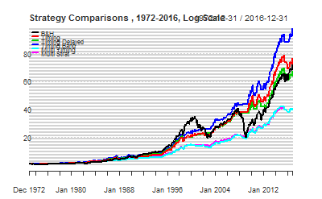

```r
Returns <- cbind.xts(AllAssets.xts$SP500.ret,
                     AllAssets.xts$SP500.10m.timingret,
                     AllAssets.xts$SP500.10m.timingret.delayed,
                     AllAssets.xts$SP500.10m.timingret.band,
                     AllAssets.xts$SP500.avg.timingret,
                     AllAssets.xts$SP500.avg.combo.band)[SubsetPeriod.Reporting]
colnames(Returns) <- Strategies
chart.CumReturns(Returns, wealth.index = TRUE,
  main = paste("Strategy Comparisons , ", substr(SubsetPeriod.Reporting,1,4),"-", substr(SubsetPeriod.Reporting,13,16),", Log Scale",sep = ""),
  #colorset = c(4,2,3,5,6),
  legend.loc = "topleft",
  date.format = "%Y", ylab = "", ylog = TRUE)
```

[output not shown]

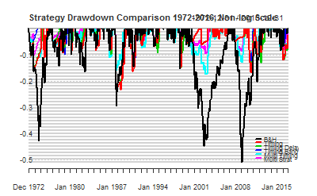

```r
chart.Drawdown(Returns,#[,-1], to exclude B&H
  main = paste("Strategy Drawdown Comparison ",substr(SubsetPeriod.Reporting,1,4),"-",substr(SubsetPeriod.Reporting,13,16),", Non-log Scale",sep = ""),
  date.format = "%Y", #colorset = c(4,2,3,5,6),
  ylab = "Drawdown", legend.loc = "bottomright", major.ticks = "years",  minor.ticks = FALSE)
```

```r
TimeInMarket <- c(nrow(AllAssets.xts[SubsetPeriod.Reporting]),
                  sum(AllAssets.xts$SP500.10m.signal[SubsetPeriod.Reporting]),
                  sum(AllAssets.xts$SP500.10m.signal.delayed[SubsetPeriod.Reporting]),
                  sum(AllAssets.xts$SP500.10m.signal.band[SubsetPeriod.Reporting]),
                  sum(AllAssets.xts$SP500.avg.signal[SubsetPeriod.Reporting]),
                  sum(AllAssets.xts$SP500.avg.combo.band.signal[SubsetPeriod.Reporting]))/nrow(AllAssets.xts[SubsetPeriod.Reporting])
FullStats <- rbind(Return.annualized(Returns,scale = 12)*FormatMultiplier,
                   StdDev.annualized(Returns,scale = 12)*FormatMultiplier,
                   skewness(Returns),
                   kurtosis(Returns),
                   100*c(Return.annualized(AllAssets.ret$CPI[SubsetPeriod.Reporting],scale = 12)),
                   TimeInMarket*FormatMultiplier,
                   apply(Returns, 2, function(x) length(x[x>0]))/nrow(Returns)*FormatMultiplier,
                   apply(Returns, 2, function(x) max(x, na.rm = TRUE))*FormatMultiplier,
                   apply(Returns, 2, function(x) min(x, na.rm = TRUE))*FormatMultiplier,
                   maxDrawdown(Returns,scale = 12,invert = FALSE)*FormatMultiplier,
                   -maxDrawdown(Returns,scale = 12,invert = FALSE)/Return.annualized(Returns,scale = 12),
                   SharpeRatio.annualized(Returns,Rf = AllAssets.ret$TBILLS[SubsetPeriod.Reporting]),
                   #SharpeRatio.annualized(Returns,Rf = Rf.ret$TBILLYIELDS.Close),
                   SortinoRatio(Returns, scale = 12), #what MAR?
                   CalmarRatio(Returns, scale = 12),
                   UlcerIndex(Returns)*FormatMultiplier)
colnames(FullStats) <- Strategies

rownames(FullStats) <- PerformanceMeasures
round(FullStats,2)
```

|  | B&H | Timing | Timing Delayed | Timing Band | Multi Timing | Multi Strat |
| --- | --- | --- | --- | --- | --- | --- |
| CAGR | 10.19 | 10.35 | 10.03 | 10.96 | 8.79 | 8.78 |
| Volatility | 15.28 | 11.61 | 11.22 | 11.14 | 9.96 | 8.88 |
| Skew | -0.43 | -0.68 | -0.71 | -0.66 | -0.38 | -0.33 |
| Kurtosis | 1.97 | 5.19 | 6.13 | 6.13 | 2.62 | 3.95 |
| Inflation CAGR | 4.04 | 4.04 | 4.04 | 4.04 | 4.04 | 4.04 |
| % in the Market | 100.00 | 74.67 | 69.19 | 70.89 | 68.30 | 58.83 |
| % positive Months | 61.63 | 73.35 | 75.24 | 75.24 | 70.13 | 71.46 |
| Best Month | 16.81 | 13.47 | 13.47 | 13.47 | 11.51 | 11.51 |
| Worst Month | -21.54 | -21.54 | -21.54 | -21.54 | -14.17 | -14.17 |
| Max Drawdown | -50.95 | -23.29 | -23.26 | -23.29 | -17.49 | -15.80 |

[output cut: 5 more lines]

```r
write.table(round(FullStats,4), "clipboard", sep="\t", col.names=NA)
```

#### EAFE

[output not shown]

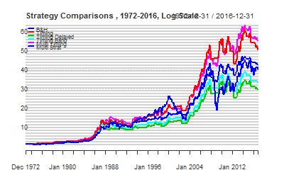

```r
Returns <- cbind.xts(AllAssets.xts$EAFE.ret,
                     AllAssets.xts$EAFE.10m.timingret,
                     AllAssets.xts$EAFE.10m.timingret.delayed,
                     AllAssets.xts$EAFE.10m.timingret.band,
                     AllAssets.xts$EAFE.avg.timingret,
                     AllAssets.xts$EAFE.avg.combo.band)[SubsetPeriod.Reporting]
colnames(Returns) <- Strategies
chart.CumReturns(Returns, wealth.index = TRUE,
  main = paste("Strategy Comparisons , ", substr(SubsetPeriod.Reporting,1,4),"-", substr(SubsetPeriod.Reporting,13,16),", Log Scale",sep = ""),
  colorset = c(4,2,3,5,6),legend.loc = "topleft",
  date.format = "%Y", ylab = "", ylog = TRUE)
```

[output not shown]

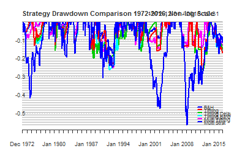

```r
chart.Drawdown(Returns,#[,-1], to exclude B&H
  main = paste("Strategy Drawdown Comparison ",substr(SubsetPeriod.Reporting,1,4),"-",substr(SubsetPeriod.Reporting,13,16),", Non-log Scale",sep = ""),
  date.format = "%Y", colorset = c(4,2,3,5,6),
  ylab = "Drawdown", legend.loc = "bottomright", major.ticks = "years",  minor.ticks = FALSE)
```

```r
TimeInMarket <- c(nrow(AllAssets.xts[SubsetPeriod.Reporting]),
                  sum(AllAssets.xts$EAFE.10m.signal[SubsetPeriod.Reporting]),
                  sum(AllAssets.xts$EAFE.10m.signal.delayed[SubsetPeriod.Reporting]),
                  sum(AllAssets.xts$EAFE.10m.signal.band[SubsetPeriod.Reporting]),
                  sum(AllAssets.xts$EAFE.avg.signal[SubsetPeriod.Reporting]),
                  sum(AllAssets.xts$EAFE.avg.combo.signal[SubsetPeriod.Reporting]))/nrow(AllAssets.xts[SubsetPeriod.Reporting])
FullStats <- rbind(Return.annualized(Returns,scale = 12)*FormatMultiplier,
                   StdDev.annualized(Returns,scale = 12)*FormatMultiplier,
                   skewness(Returns),
                   kurtosis(Returns),
                   100*c(Return.annualized(AllAssets.ret$CPI[SubsetPeriod.Reporting],scale = 12)),
                   TimeInMarket*FormatMultiplier,
                   apply(Returns, 2, function(x) length(x[x>0]))/nrow(Returns)*FormatMultiplier,
                   apply(Returns, 2, function(x) max(x, na.rm = TRUE))*FormatMultiplier,
                   apply(Returns, 2, function(x) min(x, na.rm = TRUE))*FormatMultiplier,
                   maxDrawdown(Returns,scale = 12,invert = FALSE)*FormatMultiplier,
                   -maxDrawdown(Returns,scale = 12,invert = FALSE)/Return.annualized(Returns,scale = 12),
                   SharpeRatio.annualized(Returns,Rf = AllAssets.ret$TBILLS[SubsetPeriod.Reporting]),
                   SortinoRatio(Returns, scale = 12), #what MAR?
                   CalmarRatio(Returns, scale = 12),
                   UlcerIndex(Returns)*FormatMultiplier)
colnames(FullStats) <- Strategies
rownames(FullStats) <- PerformanceMeasures
round(FullStats,2)
```

|  | B&H | Timing | Timing Delayed | Timing Band | Multi Timing | Multi Strat |
| --- | --- | --- | --- | --- | --- | --- |
| CAGR | 8.81 | 9.31 | 7.97 | 8.27 | 9.51 | 8.88 |
| Volatility | 17.20 | 12.37 | 11.73 | 12.06 | 11.24 | 9.86 |
| Skew | -0.29 | -0.23 | -0.36 | -0.24 | 0.16 | 0.21 |
| Kurtosis | 1.02 | 2.26 | 2.82 | 2.64 | 2.09 | 3.03 |
| Inflation CAGR | 4.04 | 4.04 | 4.04 | 4.04 | 4.04 | 4.04 |
| % in the Market | 100.00 | 69.19 | 62.95 | 64.27 | 64.02 | 57.12 |
| % positive Months | 59.17 | 72.97 | 75.24 | 74.10 | 69.19 | 70.51 |
| Best Month | 17.87 | 14.09 | 14.09 | 14.09 | 14.09 | 14.09 |
| Worst Month | -20.17 | -13.99 | -13.99 | -13.99 | -12.37 | -10.95 |
| Max Drawdown | -56.40 | -25.49 | -26.34 | -26.33 | -25.12 | -17.14 |

[output cut: 5 more lines]

```r
write.table(round(FullStats,4), "clipboard", sep="\t", col.names=NA)
```

#### US10YR

[output not shown]

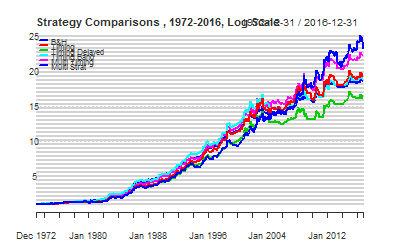

```r
Returns <- cbind.xts(AllAssets.xts$US10YR.ret,
                     AllAssets.xts$US10YR.10m.timingret,
                     AllAssets.xts$US10YR.10m.timingret.delayed,
                     AllAssets.xts$US10YR.10m.timingret.band,
                     AllAssets.xts$US10YR.avg.timingret,
                     AllAssets.xts$US10YR.avg.combo.band)[SubsetPeriod.Reporting]
colnames(Returns) <- Strategies
chart.CumReturns(Returns, wealth.index = TRUE,
  main = paste("Strategy Comparisons , ", substr(SubsetPeriod.Reporting,1,4),"-", substr(SubsetPeriod.Reporting,13,16),", Log Scale",sep = ""),
  colorset = c(4,2,3,5,6),legend.loc = "topleft",
  date.format = "%Y", ylab = "", ylog = TRUE)
```

[output not shown]

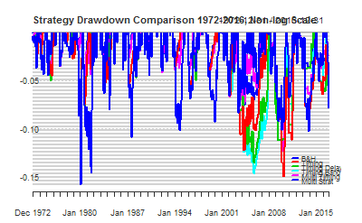

```r
chart.Drawdown(Returns,#[,-1], to exclude B&H
  main = paste("Strategy Drawdown Comparison ",substr(SubsetPeriod.Reporting,1,4),"-",substr(SubsetPeriod.Reporting,13,16),", Non-log Scale",sep = ""),
  date.format = "%Y", colorset = c(4,2,3,5,6),
  ylab = "Drawdown", legend.loc = "bottomright", major.ticks = "years",  minor.ticks = FALSE)
```

```r
TimeInMarket <- c(nrow(AllAssets.xts[SubsetPeriod.Reporting]),
                  sum(AllAssets.xts$US10YR.10m.signal[SubsetPeriod.Reporting]),
                  sum(AllAssets.xts$US10YR.10m.signal.delayed[SubsetPeriod.Reporting]),
                  sum(AllAssets.xts$US10YR.10m.signal.band[SubsetPeriod.Reporting]),
                  sum(AllAssets.xts$US10YR.avg.signal[SubsetPeriod.Reporting]),
                  sum(AllAssets.xts$US10YR.avg.combo.band.signal[SubsetPeriod.Reporting]))/nrow(AllAssets.xts[SubsetPeriod.Reporting])
FullStats <- rbind(Return.annualized(Returns,scale = 12)*FormatMultiplier,
                   StdDev.annualized(Returns,scale = 12)*FormatMultiplier,
                   skewness(Returns),
                   kurtosis(Returns),
                   100*c(Return.annualized(AllAssets.ret$CPI[SubsetPeriod.Reporting],scale = 12)),
                   TimeInMarket*FormatMultiplier,
                   apply(Returns, 2, function(x) length(x[x>0]))/nrow(Returns)*FormatMultiplier,
                   apply(Returns, 2, function(x) max(x, na.rm = TRUE))*FormatMultiplier,
                   apply(Returns, 2, function(x) min(x, na.rm = TRUE))*FormatMultiplier,
                   maxDrawdown(Returns,scale = 12,invert = FALSE)*FormatMultiplier,
                   -maxDrawdown(Returns,scale = 12,invert = FALSE)/Return.annualized(Returns,scale = 12),
                   SharpeRatio.annualized(Returns,Rf = AllAssets.ret$TBILLS[SubsetPeriod.Reporting]),
                   SortinoRatio(Returns, scale = 12), #what MAR?
                   CalmarRatio(Returns, scale = 12),
                   UlcerIndex(Returns)*FormatMultiplier)
colnames(FullStats) <- Strategies
rownames(FullStats) <- PerformanceMeasures
round(FullStats,2)
```

|  | B&H | Timing | Timing Delayed | Timing Band | Multi Timing | Multi Strat |
| --- | --- | --- | --- | --- | --- | --- |
| CAGR | 7.38 | 6.94 | 6.52 | 6.92 | 7.29 | 6.86 |
| Volatility | 8.32 | 7.08 | 6.61 | 6.73 | 6.55 | 5.52 |
| Skew | 0.35 | 0.22 | 0.13 | 0.32 | 0.48 | 0.52 |
| Kurtosis | 1.93 | 2.00 | 2.21 | 2.78 | 2.36 | 3.13 |
| Inflation CAGR | 4.04 | 4.04 | 4.04 | 4.04 | 4.04 | 4.04 |
| % in the Market | 100.00 | 74.29 | 67.67 | 63.89 | 67.86 | 54.00 |
| % positive Months | 60.11 | 70.89 | 73.72 | 75.80 | 70.51 | 73.35 |
| Best Month | 12.40 | 9.44 | 7.91 | 9.44 | 9.44 | 7.33 |
| Worst Month | -7.93 | -7.29 | -7.29 | -7.29 | -5.17 | -5.17 |
| Max Drawdown | -15.75 | -14.91 | -13.52 | -14.65 | -12.25 | -9.18 |

[output cut: 5 more lines]

```r
write.table(round(FullStats,4), "clipboard", sep="\t", col.names=NA)
```

#### GSCI

[output not shown]

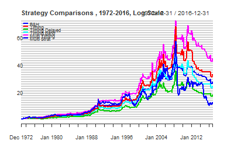

```r
Returns <- cbind.xts(AllAssets.xts$GSCI.ret,
                     AllAssets.xts$GSCI.10m.timingret,
                     AllAssets.xts$GSCI.10m.timingret.delayed,
                     AllAssets.xts$GSCI.10m.timingret.band,
                     AllAssets.xts$GSCI.avg.timingret,
                     AllAssets.xts$GSCI.avg.combo.band)[SubsetPeriod.Reporting]
colnames(Returns) <- Strategies
chart.CumReturns(Returns, wealth.index = TRUE,
  main = paste("Strategy Comparisons , ", substr(SubsetPeriod.Reporting,1,4),"-", substr(SubsetPeriod.Reporting,13,16),", Log Scale",sep = ""),
  colorset = c(4,2,3,5,6),legend.loc = "topleft",
  date.format = "%Y", ylab = "", ylog = TRUE)
```

[output not shown]

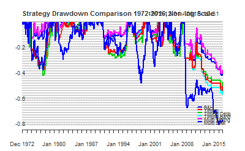

```r
chart.Drawdown(Returns,#[,-1], to exclude B&H
  main = paste("Strategy Drawdown Comparison ",substr(SubsetPeriod.Reporting,1,4),"-",substr(SubsetPeriod.Reporting,13,16),", Non-log Scale",sep = ""),
  date.format = "%Y", colorset = c(4,2,3,5,6),
  ylab = "Drawdown", legend.loc = "bottomright", major.ticks = "years",  minor.ticks = FALSE)
```

```r
TimeInMarket <- c(nrow(AllAssets.xts[SubsetPeriod.Reporting]),
                  sum(AllAssets.xts$GSCI.10m.signal[SubsetPeriod.Reporting]),
                  sum(AllAssets.xts$GSCI.10m.signal.delayed[SubsetPeriod.Reporting]),
                  sum(AllAssets.xts$GSCI.10m.signal.band[SubsetPeriod.Reporting]),
                  sum(AllAssets.xts$GSCI.avg.signal[SubsetPeriod.Reporting]),
                  sum(AllAssets.xts$GSCI.avg.combo.band.signal[SubsetPeriod.Reporting]))/nrow(AllAssets.xts[SubsetPeriod.Reporting])
FullStats <- rbind(Return.annualized(Returns,scale = 12)*FormatMultiplier,
                   StdDev.annualized(Returns,scale = 12)*FormatMultiplier,
                   skewness(Returns),
                   kurtosis(Returns),
                   100*c(Return.annualized(AllAssets.ret$CPI[SubsetPeriod.Reporting],scale = 12)),
                   TimeInMarket*FormatMultiplier,
                   apply(Returns, 2, function(x) length(x[x>0]))/nrow(Returns)*FormatMultiplier,
                   apply(Returns, 2, function(x) max(x, na.rm = TRUE))*FormatMultiplier,
                   apply(Returns, 2, function(x) min(x, na.rm = TRUE))*FormatMultiplier,
                   maxDrawdown(Returns,scale = 12,invert = FALSE)*FormatMultiplier,
                   -maxDrawdown(Returns,scale = 12,invert = FALSE)/Return.annualized(Returns,scale = 12),
                   SharpeRatio.annualized(Returns,Rf = AllAssets.ret$TBILLS[SubsetPeriod.Reporting]),
                   SortinoRatio(Returns, scale = 12), #what MAR?
                   CalmarRatio(Returns, scale = 12),
                   UlcerIndex(Returns)*FormatMultiplier)
colnames(FullStats) <- Strategies
rownames(FullStats) <- PerformanceMeasures
round(FullStats,2)
```

|  | B&H | Timing | Timing Delayed | Timing Band | Multi Timing | Multi Strat |
| --- | --- | --- | --- | --- | --- | --- |
| CAGR | 6.02 | 8.31 | 6.90 | 7.61 | 9.03 | 7.85 |
| Volatility | 20.53 | 16.22 | 15.59 | 16.05 | 14.11 | 12.85 |
| Skew | 0.04 | 0.62 | 0.51 | 0.67 | 0.83 | 0.66 |
| Kurtosis | 2.21 | 4.68 | 4.70 | 5.02 | 5.49 | 5.72 |
| Inflation CAGR | 4.04 | 4.04 | 4.04 | 4.04 | 4.04 | 4.04 |
| % in the Market | 100.00 | 62.76 | 55.20 | 56.33 | 59.48 | 50.05 |
| % positive Months | 56.33 | 73.72 | 76.18 | 75.80 | 67.86 | 70.32 |
| Best Month | 25.77 | 25.77 | 25.77 | 25.77 | 23.83 | 22.94 |
| Worst Month | -28.20 | -15.63 | -15.63 | -15.63 | -14.41 | -14.41 |
| Max Drawdown | -80.90 | -53.93 | -51.12 | -56.67 | -40.79 | -41.84 |

[output cut: 5 more lines]

```r
write.table(round(FullStats,4), "clipboard", sep="\t", col.names=NA)
```

#### NAREIT

[output not shown]

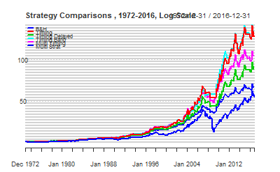

```r
Returns <- cbind.xts(AllAssets.xts$NAREIT.ret,
                     AllAssets.xts$NAREIT.10m.timingret,
                     AllAssets.xts$NAREIT.10m.timingret.delayed,
                     AllAssets.xts$NAREIT.10m.timingret.band,
                     AllAssets.xts$NAREIT.avg.timingret,
                     AllAssets.xts$NAREIT.avg.combo.band)[SubsetPeriod.Reporting]
colnames(Returns) <- Strategies
chart.CumReturns(Returns, wealth.index = TRUE,
  main = paste("Strategy Comparisons , ", substr(SubsetPeriod.Reporting,1,4),"-", substr(SubsetPeriod.Reporting,13,16),", Log Scale",sep = ""),
  colorset = c(4,2,3,5,6),legend.loc = "topleft",
  date.format = "%Y", ylab = "", ylog = TRUE)
```

[output not shown]

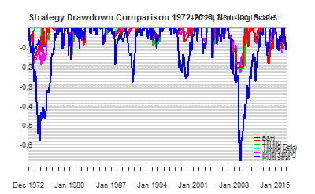

```r
chart.Drawdown(Returns,#[,-1], to exclude B&H
  main = paste("Strategy Drawdown Comparison ",substr(SubsetPeriod.Reporting,1,4),"-",substr(SubsetPeriod.Reporting,13,16),", Non-log Scale",sep = ""),
  date.format = "%Y", colorset = c(4,2,3,5,6),
  ylab = "Drawdown", legend.loc = "bottomright", major.ticks = "years",  minor.ticks = FALSE)
```

```r
TimeInMarket <- c(nrow(AllAssets.xts[SubsetPeriod.Reporting]),
                  sum(AllAssets.xts$NAREIT.10m.signal[SubsetPeriod.Reporting]),
                  sum(AllAssets.xts$NAREIT.10m.signal.delayed[SubsetPeriod.Reporting]),
                  sum(AllAssets.xts$NAREIT.10m.signal.band[SubsetPeriod.Reporting]),
                  sum(AllAssets.xts$NAREIT.avg.signal[SubsetPeriod.Reporting]),
                  sum(AllAssets.xts$NAREIT.avg.combo.band.signal[SubsetPeriod.Reporting]))/nrow(AllAssets.xts[SubsetPeriod.Reporting])
FullStats <- rbind(Return.annualized(Returns,scale = 12)*FormatMultiplier,
                   StdDev.annualized(Returns,scale = 12)*FormatMultiplier,
                   skewness(Returns),
                   kurtosis(Returns),
                   100*c(Return.annualized(AllAssets.ret$CPI[SubsetPeriod.Reporting],scale = 12)),
                   TimeInMarket*FormatMultiplier,
                   apply(Returns, 2, function(x) length(x[x>0]))/nrow(Returns)*FormatMultiplier,
                   apply(Returns, 2, function(x) max(x, na.rm = TRUE))*FormatMultiplier,
                   apply(Returns, 2, function(x) min(x, na.rm = TRUE))*FormatMultiplier,
                   maxDrawdown(Returns,scale = 12,invert = FALSE)*FormatMultiplier,
                   -maxDrawdown(Returns,scale = 12,invert = FALSE)/Return.annualized(Returns,scale = 12),
                   SharpeRatio.annualized(Returns,Rf = AllAssets.ret$TBILLS[SubsetPeriod.Reporting]),
                   SortinoRatio(Returns, scale = 12), #what MAR?
                   CalmarRatio(Returns, scale = 12),
                   UlcerIndex(Returns)*FormatMultiplier)
colnames(FullStats) <- Strategies
rownames(FullStats) <- PerformanceMeasures
round(FullStats,2)
```

|  | B&H | Timing | Timing Delayed | Timing Band | Multi Timing | Multi Strat |
| --- | --- | --- | --- | --- | --- | --- |
| CAGR | 9.63 | 11.64 | 10.70 | 11.65 | 11.12 | 10.00 |
| Volatility | 17.80 | 11.81 | 11.02 | 11.08 | 10.97 | 9.62 |
| Skew | -0.39 | -0.33 | -0.39 | -0.24 | -0.27 | -0.40 |
| Kurtosis | 7.20 | 3.23 | 3.16 | 3.02 | 3.67 | 4.19 |
| Inflation CAGR | 4.04 | 4.04 | 4.04 | 4.04 | 4.04 | 4.04 |
| % in the Market | 100.00 | 73.16 | 68.05 | 69.19 | 67.30 | 57.95 |
| % positive Months | 62.00 | 73.91 | 75.61 | 75.43 | 71.64 | 73.35 |
| Best Month | 30.81 | 14.57 | 10.97 | 12.51 | 14.57 | 10.97 |
| Worst Month | -30.54 | -15.26 | -15.26 | -15.26 | -15.26 | -15.26 |
| Max Drawdown | -68.18 | -20.64 | -21.22 | -16.42 | -22.66 | -20.74 |

[output cut: 5 more lines]

```r
write.table(round(FullStats,4), "clipboard", sep="\t", col.names=NA)
```

#### GTAA Replication

[output not shown]

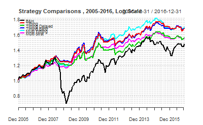

```r
SubsetPeriod.Faber <- "2005-12-31::2016-12-31" #"1972-12-31::2005-12-31" #"1972-12-31::2012-12-31"
Returns <- cbind.xts(AllAssets.xts$BuyandHold.ret,
                     AllAssets.xts$Timing.ret,
                     AllAssets.xts$DelayedTiming.ret,
                     AllAssets.xts$BandTiming.ret,
                     AllAssets.xts$Avg.Timing.ret,
                     AllAssets.xts$Avg.Combo.Band.ret)[SubsetPeriod.Faber]
colnames(Returns) <- Strategies
chart.CumReturns(Returns, wealth.index = TRUE,
  main = paste("Strategy Comparisons , ", substr(SubsetPeriod.Faber,1,4),"-", substr(SubsetPeriod.Faber,13,16),", Log Scale",sep = ""),
  #colorset = c(4,2,3,5,6),
  legend.loc = "topleft",
  date.format = "%Y", ylab = "", ylog = TRUE)
```

[output not shown]

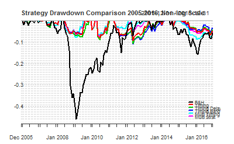

```r
chart.Drawdown(Returns,#[,-1], to exclude B&H
  main = paste("Strategy Drawdown Comparison ",substr(SubsetPeriod.Faber,1,4),"-",substr(SubsetPeriod.Faber,13,16),", Non-log Scale",sep = ""),
  date.format = "%Y", #colorset = c(4,2,3,5,6),
  ylab = "Drawdown", legend.loc = "bottomright", major.ticks = "years",  minor.ticks = FALSE)
```

```r
TimeInMarket <- c(nrow(AllAssets.xts[SubsetPeriod.Faber]),
                  sum(AllAssets.xts$Timing.signal[SubsetPeriod.Faber]),
                  sum(AllAssets.xts$DelayedTiming.signal[SubsetPeriod.Faber]),
                  sum(AllAssets.xts$BandTiming.signal[SubsetPeriod.Faber]),
                  sum(AllAssets.xts$Avg.Timing.signal[SubsetPeriod.Faber]),
                  sum(AllAssets.xts$Avg.Combo.signal[SubsetPeriod.Faber]))/nrow(AllAssets.xts[SubsetPeriod.Faber])
FullStats <- rbind(Return.annualized(Returns,scale = 12)*FormatMultiplier,
                   StdDev.annualized(Returns,scale = 12)*FormatMultiplier,
                   skewness(Returns),
                   kurtosis(Returns),
                   100*c(Return.annualized(AllAssets.ret$CPI[SubsetPeriod.Faber],scale = 12)),
                   TimeInMarket*FormatMultiplier,
                   apply(Returns, 2, function(x) length(x[x>0]))/nrow(Returns)*FormatMultiplier,
                   apply(Returns, 2, function(x) max(x, na.rm = TRUE))*FormatMultiplier,
                   apply(Returns, 2, function(x) min(x, na.rm = TRUE))*FormatMultiplier,
                   maxDrawdown(Returns,scale = 12,invert = FALSE)*FormatMultiplier,
                   -maxDrawdown(Returns,scale = 12,invert = FALSE)/Return.annualized(Returns,scale = 12),
                   SharpeRatio.annualized(Returns,Rf = AllAssets.ret$TBILLS[SubsetPeriod.Faber]),
                   SortinoRatio(Returns, scale = 12), #what MAR?
                   CalmarRatio(Returns, scale = 12),
                   UlcerIndex(Returns)*FormatMultiplier)
colnames(FullStats) <- Strategies
rownames(FullStats) <- PerformanceMeasures
round(FullStats,2)
```

|  | B&H | Timing | Timing Delayed | Timing Band | Multi Timing | Multi Strat |
| --- | --- | --- | --- | --- | --- | --- |
| CAGR | 3.61 | 4.84 | 4.15 | 4.89 | 4.94 | 4.08 |
| Volatility | 12.74 | 6.49 | 6.33 | 6.48 | 5.96 | 5.35 |
| Skew | -1.39 | -0.61 | -0.83 | -0.78 | -0.53 | -0.77 |
| Kurtosis | 5.76 | 1.80 | 2.79 | 2.50 | 1.15 | 2.89 |
| Inflation CAGR | 1.86 | 1.86 | 1.86 | 1.86 | 1.86 | 1.86 |
| % in the Market | 100.00 | 66.32 | 59.40 | 60.30 | 62.16 | 55.21 |
| % positive Months | 59.40 | 61.65 | 63.16 | 64.66 | 59.40 | 63.16 |
| Best Month | 9.22 | 5.00 | 5.00 | 5.00 | 4.67 | 4.67 |
| Worst Month | -19.34 | -6.87 | -7.57 | -7.57 | -6.11 | -6.57 |
| Max Drawdown | -46.10 | -9.22 | -10.50 | -10.82 | -8.65 | -6.93 |

[output cut: 5 more lines]

[output not shown]

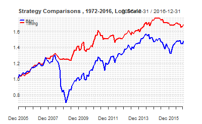

```r
write.table(round(FullStats,4), "clipboard", sep="\t", col.names=NA)
chart.CumReturns(Returns[,1:2], wealth.index = TRUE,
  main = paste("Strategy Comparisons , ", substr(SubsetPeriod.Reporting,1,4),"-", substr(SubsetPeriod.Reporting,13,16),", Log Scale",sep = ""),
  colorset = c(4,2,3,5,6),legend.loc = "topleft",
  date.format = "%Y", ylab = "", ylog = TRUE)
```

[output not shown]

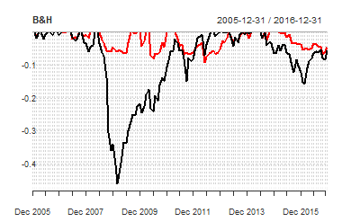

```r
chart.Drawdown(Returns[,1:2])
```

[output not shown]

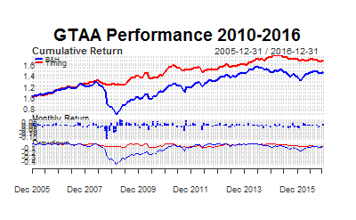

```r
charts.PerformanceSummary(Returns[,1:2], main = "GTAA Performance 2010-2016", colorset = c(4,2), wealth.index = TRUE)
```

[output not shown]

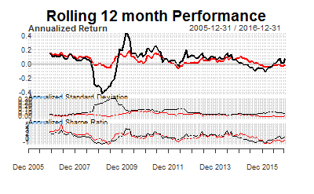

```r
charts.RollingPerformance(Returns[,1:2],
                          width = 12)
```

#### GTAA

[output not shown]

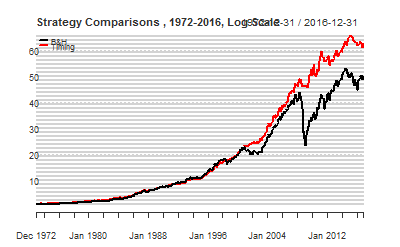

```r
Returns <- cbind.xts(AllAssets.xts$BuyandHold.ret,
                     AllAssets.xts$Timing.ret,
                     AllAssets.xts$DelayedTiming.ret,
                     AllAssets.xts$BandTiming.ret,
                     AllAssets.xts$Avg.Timing.ret,
                     AllAssets.xts$Avg.Combo.Band.ret)[SubsetPeriod.Reporting]
colnames(Returns) <- Strategies
chart.CumReturns(Returns[,1:2], wealth.index = TRUE,
  main = paste("Strategy Comparisons , ", substr(SubsetPeriod.Reporting,1,4),"-", substr(SubsetPeriod.Reporting,13,16),", Log Scale",sep = ""),
  #colorset = c(4,2,3,5,6),
  legend.loc = "topleft",
  date.format = "%Y", ylab = "", ylog = TRUE)
```

[output not shown]

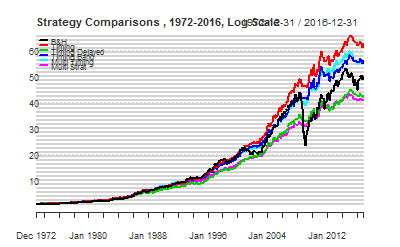

```r
chart.CumReturns(Returns, wealth.index = TRUE,
  main = paste("Strategy Comparisons , ", substr(SubsetPeriod.Reporting,1,4),"-", substr(SubsetPeriod.Reporting,13,16),", Log Scale",sep = ""),
  #colorset = c(4,2,3,5,6),
  legend.loc = "topleft",
  date.format = "%Y", ylab = "", ylog = TRUE)
```

[output not shown]

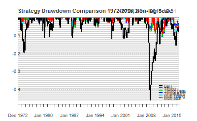

```r
chart.Drawdown(Returns,#[,-1], to exclude B&H
  main = paste("Strategy Drawdown Comparison ",substr(SubsetPeriod.Reporting,1,4),"-",substr(SubsetPeriod.Reporting,13,16),", Non-log Scale",sep = ""),
  date.format = "%Y", #colorset = c(4,2,3,5,6),
  ylab = "Drawdown", legend.loc = "bottomright", major.ticks = "years",  minor.ticks = FALSE)
```

```r
TimeInMarket <- c(nrow(AllAssets.xts[SubsetPeriod.Reporting]),
                  sum(AllAssets.xts$Timing.signal[SubsetPeriod.Reporting]),
                  sum(AllAssets.xts$DelayedTiming.signal[SubsetPeriod.Reporting]),
                  sum(AllAssets.xts$BandTiming.signal[SubsetPeriod.Reporting]),
                  sum(AllAssets.xts$Avg.Timing.signal[SubsetPeriod.Reporting]),
                  sum(AllAssets.xts$Avg.Combo.Band.signal[SubsetPeriod.Reporting]))/nrow(AllAssets.xts[SubsetPeriod.Reporting])
FullStats <- rbind(Return.annualized(Returns,scale = 12)*FormatMultiplier,
                   StdDev.annualized(Returns,scale = 12)*FormatMultiplier,
                   skewness(Returns),
                   kurtosis(Returns),
                   100*c(Return.annualized(AllAssets.ret$CPI[SubsetPeriod.Reporting],scale = 12)),
                   TimeInMarket*FormatMultiplier,
                   apply(Returns, 2, function(x) length(x[x>0]))/nrow(Returns)*FormatMultiplier,
                   apply(Returns, 2, function(x) max(x, na.rm = TRUE))*FormatMultiplier,
                   apply(Returns, 2, function(x) min(x, na.rm = TRUE))*FormatMultiplier,
                   maxDrawdown(Returns,scale = 12,invert = FALSE)*FormatMultiplier,
                   -maxDrawdown(Returns,scale = 12,invert = FALSE)/Return.annualized(Returns,scale = 12),
                   SharpeRatio.annualized(Returns,Rf = AllAssets.ret$TBILLS[SubsetPeriod.Reporting]),
                   SortinoRatio(Returns, scale = 12), #what MAR?
                   CalmarRatio(Returns, scale = 12),
                   UlcerIndex(Returns)*FormatMultiplier)
colnames(FullStats) <- Strategies
rownames(FullStats) <- PerformanceMeasures
round(FullStats,2)
```

|  | B&H | Timing | Timing Delayed | Timing Band | Multi Timing | Multi Strat |
| --- | --- | --- | --- | --- | --- | --- |
| CAGR | 9.29 | 9.84 | 8.90 | 9.57 | 9.57 | 8.80 |
| Volatility | 10.08 | 6.87 | 6.51 | 6.65 | 6.14 | 5.48 |
| Skew | -1.02 | -0.48 | -0.63 | -0.60 | -0.25 | -0.33 |
| Kurtosis | 5.06 | 2.35 | 3.17 | 2.89 | 1.30 | 2.22 |
| Inflation CAGR | 4.04 | 4.04 | 4.04 | 4.04 | 4.04 | 4.04 |
| % in the Market | 100.00 | 70.81 | 64.61 | 64.91 | 65.39 | 55.04 |
| % positive Months | 65.60 | 70.51 | 72.02 | 71.83 | 70.13 | 72.02 |
| Best Month | 9.22 | 6.58 | 6.58 | 6.58 | 6.18 | 6.18 |
| Worst Month | -19.34 | -9.29 | -9.29 | -9.29 | -6.11 | -6.57 |
| Max Drawdown | -46.10 | -9.56 | -10.50 | -10.82 | -8.65 | -6.93 |

[output cut: 5 more lines]

```r
write.table(round(FullStats,4), "clipboard", sep="\t", col.names=NA)
```

#### GTAA improvement diversification multi strat

[output not shown]

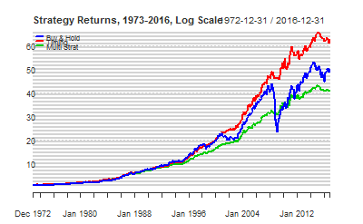

```r
Returns <- cbind.xts(AllAssets.xts$BuyandHold.ret,
                     AllAssets.xts$Timing.ret,
                     AllAssets.xts$Avg.Combo.Band.ret)[SubsetPeriod.Reporting]
colnames(Returns) <- c("Buy & Hold","Timing","Multi Strat")
chart.CumReturns(Returns, wealth.index = TRUE,
  main = "Strategy Returns, 1973-2016, Log Scale",
  colorset = c(4,2,3,5,6),legend.loc = "topleft",
  date.format = "%Y", ylab = "", ylog = TRUE)
```

[output not shown]

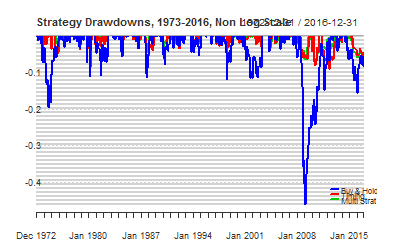

```r
chart.Drawdown(Returns,#[,-1], to exclude B&H
  main = "Strategy Drawdowns, 1973-2016, Non Log Scale",
  date.format = "%Y", colorset = c(4,2,3,5,6),
  ylab = "Drawdown", legend.loc = "bottomright", major.ticks = "years",  minor.ticks = FALSE)
```

```r
TimeInMarket <- c(nrow(AllAssets.xts[SubsetPeriod.Reporting]),
                  sum(AllAssets.xts$Timing.signal[SubsetPeriod.Reporting]),
                  sum(AllAssets.xts$Avg.Combo.Band.signal[SubsetPeriod.Reporting]))/nrow(AllAssets.xts[SubsetPeriod.Reporting])
FullStats <- rbind(Return.annualized(Returns,scale = 12)*FormatMultiplier,
                   StdDev.annualized(Returns,scale = 12)*FormatMultiplier,
                   skewness(Returns),
                   kurtosis(Returns),
                   100*c(Return.annualized(AllAssets.ret$CPI[SubsetPeriod.Reporting],scale = 12)),
                   TimeInMarket*FormatMultiplier,
                   apply(Returns, 2, function(x) length(x[x>0]))/nrow(Returns)*FormatMultiplier,
                   apply(Returns, 2, function(x) max(x, na.rm = TRUE))*FormatMultiplier,
                   apply(Returns, 2, function(x) min(x, na.rm = TRUE))*FormatMultiplier,
                   maxDrawdown(Returns,scale = 12,invert = FALSE)*FormatMultiplier,
                   -maxDrawdown(Returns,scale = 12,invert = FALSE)/Return.annualized(Returns,scale = 12),
                   SharpeRatio.annualized(Returns,Rf = AllAssets.ret$TBILLS[SubsetPeriod.Reporting]),
                   SortinoRatio(Returns, scale = 12), #what MAR?
                   CalmarRatio(Returns, scale = 12),
                   UlcerIndex(Returns)*FormatMultiplier)
colnames(FullStats) <- colnames(Returns)
rownames(FullStats) <- PerformanceMeasures
round(FullStats,2)
```

|  | Buy & Hold | Timing | Multi Strat |
| --- | --- | --- | --- |
| CAGR | 9.29 | 9.84 | 8.80 |
| Volatility | 10.08 | 6.87 | 5.48 |
| Skew | -1.02 | -0.48 | -0.33 |
| Kurtosis | 5.06 | 2.35 | 2.22 |
| Inflation CAGR | 4.04 | 4.04 | 4.04 |
| % in the Market | 100.00 | 70.81 | 55.04 |
| % positive Months | 65.60 | 70.51 | 72.02 |
| Best Month | 9.22 | 6.58 | 6.18 |
| Worst Month | -19.34 | -9.29 | -6.57 |
| Max Drawdown | -46.10 | -9.56 | -6.93 |

[output cut: 5 more lines]

```r
write.table(round(FullStats,4), "clipboard", sep="\t", col.names=NA)
```

[output not shown]

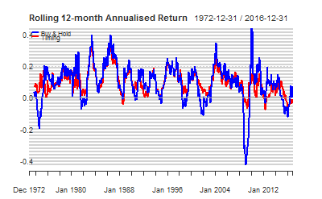

```r
chart.RollingPerformance(Returns[,1:2],
                         width = 12,
                         main = "Rolling 12-month Annualised Return",
                         colorset = c(4,2),
                         legend.loc = "topleft")
```

[output not shown]

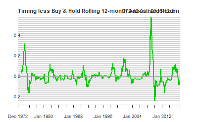

```r
chart.RollingPerformance(Returns$'Timing'-Returns$'Buy & Hold',
                         width = 12,
                         colorset = c(3),
                         main = "Timing less Buy & Hold Rolling 12-month Annualised Return"
                         )
```

[output not shown]

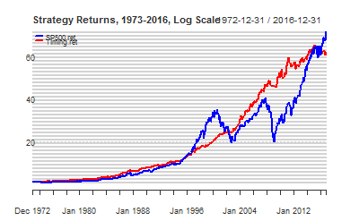

```r
SP500vsTiming <- cbind.xts(AllAssets.xts$SP500.ret,AllAssets.xts$Timing.ret)[SubsetPeriod.Reporting]
chart.CumReturns(SP500vsTiming, wealth.index = TRUE,
  main = "Strategy Returns, 1973-2016, Log Scale",
  colorset = c(4,2,3,5,6),legend.loc = "topleft",
  date.format = "%Y", ylab = "", ylog = TRUE)
```

[output not shown]

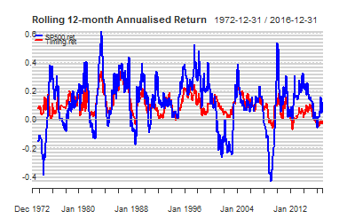

```r
chart.RollingPerformance(SP500vsTiming,
                         width = 12,
                         main = "Rolling 12-month Annualised Return",
                         colorset = c(4,2),
                         legend.loc = "topleft")
```

[output not shown]

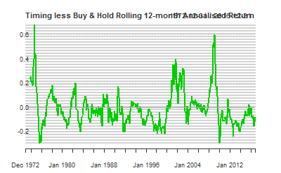

```r
chart.RollingPerformance(SP500vsTiming$'Timing.ret'-SP500vsTiming$'SP500.ret',
                         width = 12,
                         colorset = c(3),
                         main = "Timing less Buy & Hold Rolling 12-month Annualised Return"
                         )
```

#### Financialisation of Commodities

[output not shown]

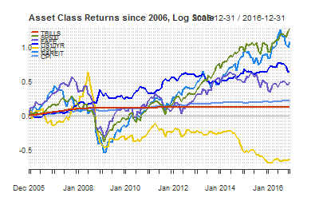

```r
SubsetPeriod.Reporting <- "2005-12-31::2016-12-31"
chart.CumReturns(AllAssets.ret[SubsetPeriod.Reporting],
 #wealth.index = TRUE,
 main = paste("Asset Class Returns since 2006, Log Scale",sep = ""),
 ylab = "",
 #ylog = TRUE,
 #ylim = c(100,250000),
 #date.format = "%Y",
 major.ticks = "years",
 legend.loc = "topleft",
 colorset = c("orangered3","olivedrab","slateblue","blue","gold2","dodgerblue2","cornflowerblue")
 #minor.ticks =FALSE
 )
```

[output not shown]

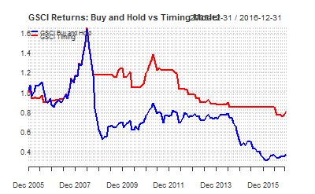

```r
Returns <- cbind.xts(AllAssets.xts$GSCI.ret,
                     AllAssets.xts$GSCI.10m.timingret)[SubsetPeriod.Reporting]
colnames(Returns) <- c("GSCI Buy and Hold","GSCI Timing")
chart.CumReturns(Returns, wealth.index = TRUE,
                 main = "GSCI Returns: Buy and Hold vs Timing Model",
                 colorset = c(4,2,3,5,6),legend.loc = "topleft", date.format = "%Y", ylab = "", ylog = TRUE)
```

[output not shown]

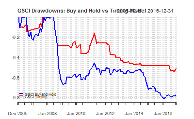

```r
chart.Drawdown(Returns, main = "GSCI Drawdowns: Buy and Hold vs Timing Model", date.format = "%Y", colorset = c(4,2,3,5,6),
               ylab = "Drawdown", legend.loc = "bottomleft", major.ticks = "years",  minor.ticks = FALSE)
```

```r
Returns <- cbind.xts(AllAssets.xts$GSCI.ret,
                     AllAssets.xts$GSCI.10m.timingret,
                     AllAssets.xts$GSCI.10m.timingret.delayed,
                     AllAssets.xts$GSCI.10m.timingret.band,
                     AllAssets.xts$GSCI.avg.timingret,
                     AllAssets.xts$GSCI.avg.combo)[SubsetPeriod.Reporting]
colnames(Returns) <- Strategies
TimeInMarket <- c(nrow(AllAssets.xts[SubsetPeriod.Reporting]),
                  sum(AllAssets.xts$GSCI.10m.signal[SubsetPeriod.Reporting]),
                  sum(AllAssets.xts$GSCI.10m.signal.delayed[SubsetPeriod.Reporting]),
                  sum(AllAssets.xts$GSCI.10m.signal.band[SubsetPeriod.Reporting]),
                  sum(AllAssets.xts$GSCI.avg.signal[SubsetPeriod.Reporting]),
                  sum(AllAssets.xts$GSCI.avg.combo.signal[SubsetPeriod.Reporting]))/nrow(AllAssets.xts[SubsetPeriod.Reporting])
FullStats <- rbind(Return.annualized(Returns,scale = 12)*FormatMultiplier,
                   StdDev.annualized(Returns,scale = 12)*FormatMultiplier,
                   skewness(Returns),
                   kurtosis(Returns),
                   100*c(Return.annualized(AllAssets.ret$CPI[SubsetPeriod.Reporting],scale = 12)),
                   TimeInMarket*FormatMultiplier,
                   apply(Returns, 2, function(x) length(x[x>0]))/nrow(Returns)*FormatMultiplier,
                   apply(Returns, 2, function(x) max(x, na.rm = TRUE))*FormatMultiplier,
                   apply(Returns, 2, function(x) min(x, na.rm = TRUE))*FormatMultiplier,
                   maxDrawdown(Returns,scale = 12,invert = FALSE)*FormatMultiplier,
                   -maxDrawdown(Returns,scale = 12,invert = FALSE)/Return.annualized(Returns,scale = 12),
                   SharpeRatio.annualized(Returns,Rf = AllAssets.ret$TBILLS[SubsetPeriod.Reporting]),
                   SortinoRatio(Returns, scale = 12), #what MAR?
                   CalmarRatio(Returns, scale = 12),
                   UlcerIndex(Returns)*FormatMultiplier)
colnames(FullStats) <- Strategies
rownames(FullStats) <- PerformanceMeasures
round(FullStats,2)
```

|  | B&H | Timing | Timing Delayed | Timing Band | Multi Timing | Multi Strat |
| --- | --- | --- | --- | --- | --- | --- |
| CAGR | -8.47 | -1.82 | -1.97 | -2.67 | -0.71 | -1.18 |
| Volatility | 23.33 | 13.95 | 13.59 | 13.79 | 12.44 | 11.56 |
| Skew | -0.60 | -0.54 | -0.60 | -0.52 | -0.58 | -0.76 |
| Kurtosis | 1.54 | 2.94 | 3.52 | 3.15 | 2.96 | 3.93 |
| Inflation CAGR | 1.86 | 1.86 | 1.86 | 1.86 | 1.86 | 1.86 |
| % in the Market | 100.00 | 47.37 | 36.84 | 41.35 | 49.37 | 41.35 |
| % positive Months | 52.63 | 76.69 | 81.95 | 78.20 | 66.92 | 67.67 |
| Best Month | 19.67 | 11.26 | 11.26 | 11.26 | 9.61 | 9.40 |
| Worst Month | -28.20 | -13.19 | -13.19 | -13.19 | -13.19 | -13.19 |
| Max Drawdown | -80.90 | -53.93 | -51.12 | -56.67 | -40.79 | -40.60 |

[output cut: 5 more lines]

[output not shown]

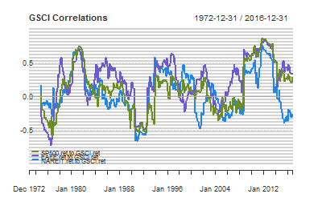

```r
write.table(round(FullStats,4), "clipboard", sep="\t", col.names=NA)
SubsetPeriod.Reporting <- "1972-12-31::2016-12-31"
CorrelationData <- cbind.xts(AllAssets.xts$SP500.ret,
                             AllAssets.xts$EAFE.ret,
                             AllAssets.xts$NAREIT.ret)[SubsetPeriod.Reporting]
chart.RollingCorrelation(CorrelationData, AllAssets.xts$GSCI.ret[SubsetPeriod.Reporting],
                         main = "GSCI Correlations",
                         width = 24, legend.loc = "bottomleft", colorset = c("olivedrab","slateblue","dodgerblue2"))
```

[output not shown]

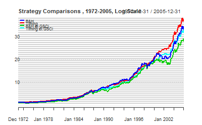

```r
#GTAA without commodities
SubsetPeriod.Reporting <- "1972-12-31::2005-12-31" #"2005-12-31::2016-12-31"
Returns <- cbind.xts(AllAssets.xts$BuyandHold.ret,
                     AllAssets.xts$Timing.ret,
                     AllAssets.xts$BuyandHold.exGSCI.ret,
                     AllAssets.xts$Timing.exGSCI.ret)[SubsetPeriod.Reporting]
colnames(Returns) <- c("B&H","Timing","B&H ex GSCI","Timing ex GSCI")
chart.CumReturns(Returns, wealth.index = TRUE,
  main = paste("Strategy Comparisons , ", substr(SubsetPeriod.Reporting,1,4),"-", substr(SubsetPeriod.Reporting,13,16),", Log Scale",sep = ""),
  colorset = c(4,2,3,5,6),legend.loc = "topleft",
  date.format = "%Y", ylab = "", ylog = TRUE)
```

[output not shown]

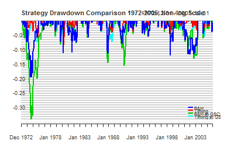

```r
chart.Drawdown(Returns,#[,-1], to exclude B&H
  main = paste("Strategy Drawdown Comparison ",substr(SubsetPeriod.Reporting,1,4),"-",substr(SubsetPeriod.Reporting,13,16),", Non-log Scale",sep = ""),
  date.format = "%Y", colorset = c(4,2,3,5,6),
  ylab = "Drawdown", legend.loc = "bottomright", major.ticks = "years",  minor.ticks = FALSE)
```

```r
TimeInMarket <- c(nrow(AllAssets.xts[SubsetPeriod.Reporting]),
                  sum(AllAssets.xts$Timing.signal[SubsetPeriod.Faber]),
                  nrow(AllAssets.xts[SubsetPeriod.Reporting]),
                  sum(AllAssets.xts$Timing.exGSCI.signal[SubsetPeriod.Faber]))/nrow(AllAssets.xts[SubsetPeriod.Reporting])
FullStats <- rbind(Return.annualized(Returns,scale = 12)*FormatMultiplier,
                   StdDev.annualized(Returns,scale = 12)*FormatMultiplier,
                   skewness(Returns),
                   kurtosis(Returns),
                   100*c(Return.annualized(AllAssets.ret$CPI[SubsetPeriod.Reporting],scale = 12)),
                   TimeInMarket*FormatMultiplier,
                   apply(Returns, 2, function(x) length(x[x>0]))/nrow(Returns)*FormatMultiplier,
                   apply(Returns, 2, function(x) max(x, na.rm = TRUE))*FormatMultiplier,
                   apply(Returns, 2, function(x) min(x, na.rm = TRUE))*FormatMultiplier,
                   maxDrawdown(Returns,scale = 12,invert = FALSE)*FormatMultiplier,
                   -maxDrawdown(Returns,scale = 12,invert = FALSE)/Return.annualized(Returns,scale = 12),
                   SharpeRatio.annualized(Returns,Rf = AllAssets.ret$TBILLS[SubsetPeriod.Reporting]),
                   SortinoRatio(Returns, scale = 12), #what MAR?
                   CalmarRatio(Returns, scale = 12),
                   UlcerIndex(Returns)*FormatMultiplier)
colnames(FullStats) <- colnames(Returns)
rownames(FullStats) <- PerformanceMeasures
round(FullStats,2)
```

|  | B&H | Timing | B&H ex GSCI | Timing ex GSCI |
| --- | --- | --- | --- | --- |
| CAGR | 11.30 | 11.58 | 10.73 | 11.15 |
| Volatility | 8.98 | 6.93 | 10.33 | 7.43 |
| Skew | -0.45 | -0.48 | -0.25 | -0.53 |
| Kurtosis | 1.48 | 2.57 | 2.39 | 3.08 |
| Inflation CAGR | 4.77 | 4.77 | 4.77 | 4.77 |
| % in the Market | 100.00 | 22.22 | 100.00 | 23.80 |
| % positive Months | 67.76 | 73.55 | 68.01 | 75.06 |
| Best Month | 9.10 | 6.58 | 15.28 | 8.10 |
| Worst Month | -9.23 | -9.29 | -11.03 | -8.61 |
| Max Drawdown | -19.61 | -9.56 | -34.09 | -9.23 |

[output cut: 5 more lines]

```r
write.table(round(FullStats,4), "clipboard", sep="\t", col.names=NA)
SubsetPeriod.Reporting <- "1972-12-31::2016-12-31"
Result.calc
```

[output not shown]

[output not shown]

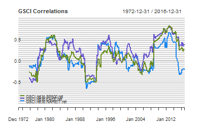

```r
chart.RollingCorrelation(AllAssets.xts$GSCI.ret[SubsetPeriod.Reporting],
                         CorrelationData[SubsetPeriod.Reporting],
                         #AllAssets.xts$GSCI.ret[SubsetPeriod.Reporting],
                         main = "GSCI Correlations",
                         width = 36, legend.loc = "bottomleft",
                         colorset = c("olivedrab","slateblue","dodgerblue2")
                         )
```

#### Multiple Averaging Periods SP500 Example - not used

[output not shown]

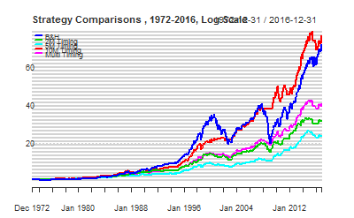

```r
#Get Returns
Returns <- cbind.xts(AllAssets.xts$SP500.ret,
                     AllAssets.xts$SP500.2m.timingret,
                     AllAssets.xts$SP500.5m.timingret,
                     AllAssets.xts$SP500.10m.timingret,
                     AllAssets.xts$SP500.avg.timingret)[SubsetPeriod.Reporting]
Strategies <- c("B&H","2M Timing","5M Timing","10M Timing","Multi Timing")
colnames(Returns) <- Strategies
chart.CumReturns(Returns, wealth.index = TRUE,
  main = paste("Strategy Comparisons , ", substr(SubsetPeriod.Reporting,1,4),"-", substr(SubsetPeriod.Reporting,13,16),", Log Scale",sep = ""),
  colorset = c(4,3,5,2,6),legend.loc = "topleft",
  date.format = "%Y", ylab = "", ylog = TRUE)
```

[output not shown]

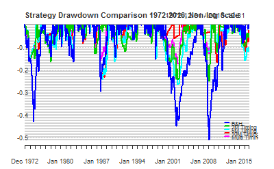

```r
chart.Drawdown(Returns,#[,-1], to exclude B&H
  main = paste("Strategy Drawdown Comparison ",substr(SubsetPeriod.Reporting,1,4),"-",substr(SubsetPeriod.Reporting,13,16),", Non-log Scale",sep = ""),
  date.format = "%Y", colorset = c(4,3,5,2,6),
  ylab = "Drawdown", legend.loc = "bottomright", major.ticks = "years",  minor.ticks = FALSE)
```

```r
TimeInMarket <- c(nrow(AllAssets.xts[SubsetPeriod.Reporting]),
                  sum(AllAssets.xts$SP500.2m.signal[SubsetPeriod.Reporting]),
                  sum(AllAssets.xts$SP500.5m.signal[SubsetPeriod.Reporting]),
                  sum(AllAssets.xts$SP500.10m.signal[SubsetPeriod.Reporting]),
                  sum(AllAssets.xts$SP500.avg.signal[SubsetPeriod.Reporting]))/nrow(AllAssets.xts[SubsetPeriod.Reporting])
FullStats <- rbind(Return.annualized(Returns,scale = 12)*FormatMultiplier,
                   StdDev.annualized(Returns,scale = 12)*FormatMultiplier,
                   skewness(Returns),
                   kurtosis(Returns),
                   100*c(Return.annualized(AllAssets.ret$CPI[SubsetPeriod.Reporting],scale = 12)),
                   TimeInMarket*FormatMultiplier,
                   apply(Returns, 2, function(x) length(x[x>0]))/nrow(Returns)*FormatMultiplier,
                   apply(Returns, 2, function(x) max(x, na.rm = TRUE))*FormatMultiplier,
                   apply(Returns, 2, function(x) min(x, na.rm = TRUE))*FormatMultiplier,
                   maxDrawdown(Returns,scale = 12,invert = FALSE)*FormatMultiplier,
                   -maxDrawdown(Returns,scale = 12,invert = FALSE)/Return.annualized(Returns,scale = 12),
                   SharpeRatio.annualized(Returns,Rf = AllAssets.ret$TBILLS[SubsetPeriod.Reporting]),
                   SortinoRatio(Returns, scale = 12), #what MAR?
                   CalmarRatio(Returns, scale = 12),
                   UlcerIndex(Returns)*FormatMultiplier)
colnames(FullStats) <- Strategies
rownames(FullStats) <- PerformanceMeasures
round(FullStats,2)
```

|  | B&H | 2M Timing | 5M Timing | 10M Timing | Multi Timing |
| --- | --- | --- | --- | --- | --- |
| CAGR | 10.19 | 8.18 | 7.50 | 10.35 | 8.79 |
| Volatility | 15.28 | 10.09 | 11.03 | 11.61 | 9.96 |
| Skew | -0.43 | -0.16 | -0.85 | -0.68 | -0.38 |
| Kurtosis | 1.97 | 2.40 | 6.17 | 5.19 | 2.62 |
| Inflation CAGR | 4.04 | 4.04 | 4.04 | 4.04 | 4.04 |
| % in the Market | 100.00 | 61.63 | 68.62 | 74.67 | 68.30 |
| % positive Months | 61.63 | 76.75 | 73.35 | 73.35 | 70.13 |
| Best Month | 16.81 | 11.51 | 12.18 | 13.47 | 11.51 |
| Worst Month | -21.54 | -11.09 | -21.54 | -21.54 | -14.17 |
| Max Drawdown | -50.95 | -24.85 | -26.35 | -23.29 | -17.49 |

[output cut: 5 more lines]

```r
write.table(round(FullStats,4), "clipboard", sep="\t", col.names=NA)
```

#### Multiple Averaging Periods GTAA Example

[output not shown]

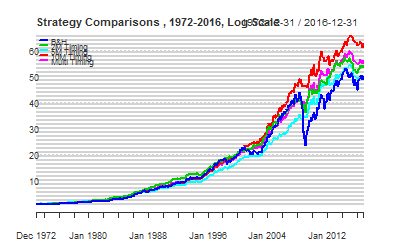

```r
#Get Returns
Returns <- cbind.xts(AllAssets.xts$BuyandHold.ret,
                     AllAssets.xts$Timing.2m.ret,
                     AllAssets.xts$Timing.5m.ret,
                     AllAssets.xts$Timing.ret,
                     AllAssets.xts$Avg.Timing.ret)[SubsetPeriod.Reporting]
Strategies <- c("B&H","2M Timing","5M Timing","10M Timing","Multi Timing")
colnames(Returns) <- Strategies
chart.CumReturns(Returns, wealth.index = TRUE,
  main = paste("Strategy Comparisons , ", substr(SubsetPeriod.Reporting,1,4),"-", substr(SubsetPeriod.Reporting,13,16),", Log Scale",sep = ""),
  colorset = c(4,3,5,2,6),legend.loc = "topleft",
  date.format = "%Y", ylab = "", ylog = TRUE)
```

[output not shown]

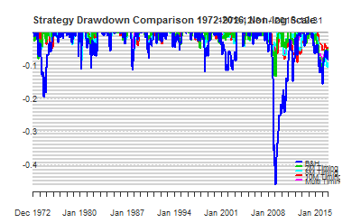

```r
chart.Drawdown(Returns,#[,-1], to exclude B&H
  main = paste("Strategy Drawdown Comparison ",substr(SubsetPeriod.Reporting,1,4),"-",substr(SubsetPeriod.Reporting,13,16),", Non-log Scale",sep = ""),
  date.format = "%Y", colorset = c(4,3,5,2,6),
  ylab = "Drawdown", legend.loc = "bottomright", major.ticks = "years",  minor.ticks = FALSE)
```

```r
TimeInMarket <- c(nrow(AllAssets.xts[SubsetPeriod.Reporting]),
                  sum(AllAssets.xts$Timing.2m.signal[SubsetPeriod.Reporting]),
                  sum(AllAssets.xts$Timing.5m.signal[SubsetPeriod.Reporting]),
                  sum(AllAssets.xts$Timing.signal[SubsetPeriod.Reporting]),
                  sum(AllAssets.xts$Avg.signal[SubsetPeriod.Reporting]))/nrow(AllAssets.xts[SubsetPeriod.Reporting])
FullStats <- rbind(Return.annualized(Returns,scale = 12)*FormatMultiplier,
                   StdDev.annualized(Returns,scale = 12)*FormatMultiplier,
                   skewness(Returns),
                   kurtosis(Returns),
                   100*c(Return.annualized(AllAssets.ret$CPI[SubsetPeriod.Reporting],scale = 12)),
                   TimeInMarket*FormatMultiplier,
                   apply(Returns, 2, function(x) length(x[x>0]))/nrow(Returns)*FormatMultiplier,
                   apply(Returns, 2, function(x) max(x, na.rm = TRUE))*FormatMultiplier,
                   apply(Returns, 2, function(x) min(x, na.rm = TRUE))*FormatMultiplier,
                   maxDrawdown(Returns,scale = 12,invert = FALSE)*FormatMultiplier,
                   -maxDrawdown(Returns,scale = 12,invert = FALSE)/Return.annualized(Returns,scale = 12),
                   SharpeRatio.annualized(Returns,Rf = AllAssets.ret$TBILLS[SubsetPeriod.Reporting]),
                   SortinoRatio(Returns, scale = 12), #what MAR?
                   CalmarRatio(Returns, scale = 12),
                   UlcerIndex(Returns)*FormatMultiplier)
colnames(FullStats) <- Strategies
rownames(FullStats) <- PerformanceMeasures
round(FullStats,2)
```

|  | B&H | 2M Timing | 5M Timing | 10M Timing | Multi Timing |
| --- | --- | --- | --- | --- | --- |
| CAGR | 9.29 | 9.49 | 9.27 | 9.84 | 9.57 |
| Volatility | 10.08 | 6.29 | 6.62 | 6.87 | 6.14 |
| Skew | -1.02 | -0.07 | -0.51 | -0.48 | -0.25 |
| Kurtosis | 5.06 | 2.55 | 2.61 | 2.35 | 1.30 |
| Inflation CAGR | 4.04 | 4.04 | 4.04 | 4.04 | 4.04 |
| % in the Market | 100.00 | 59.89 | 65.48 | 70.81 | 0.00 |
| % positive Months | 65.60 | 71.27 | 70.13 | 70.51 | 70.13 |
| Best Month | 9.22 | 9.22 | 6.57 | 6.58 | 6.18 |
| Worst Month | -19.34 | -7.96 | -9.29 | -9.29 | -6.11 |
| Max Drawdown | -46.10 | -13.29 | -10.71 | -9.56 | -8.65 |

[output cut: 5 more lines]

```r
write.table(round(FullStats,4), "clipboard", sep="\t", col.names=NA)
```

#### Performance under rising interest rates

```r
library(quantmod)
library(PerformanceAnalytics)
getSymbols("DGS10", src="FRED") #download data
```

```
[1] "DGS10"
```

```r
US10YR.yield <- to.monthly(DGS10,indexAt='lastof',drop.time=TRUE)[,4] #convert to monthly
```

```
missing values removed from data
```

[output not shown]

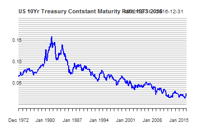

```r
chart.TimeSeries((US10YR.yield/100)[SubsetPeriod.Reporting],
 main = "US 10Yr Treasury Contstant Maturity Rate 1973-2016",
 ylab = "percent",
 #ylog = TRUE,
 ylim = c(0,0.20),
 #date.format = "%Y",
 major.ticks = "years",
 #legend.loc = "topleft",
 colorset = c("blue")
 #minor.ticks =FALSE
 )
```

[output not shown]

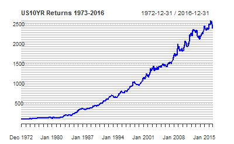

```r
chart.TimeSeries(US10YR[SubsetPeriod.Reporting],
 main = "US10YR Returns 1973-2016",
 #ylab = "percent",
 #ylog = TRUE,
 #ylim = c(0,0.20),
 #date.format = "%Y",
 major.ticks = "years",
 #legend.loc = "topleft",
 colorset = c("blue")
 #minor.ticks =FALSE
 )
```

[output not shown]

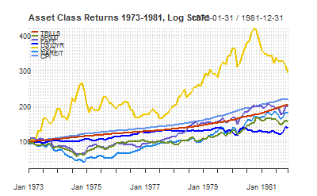

```r
SubsetPeriod.Reporting <- "1972-12-31::1981-12-31"
PerformanceMeasures <- c("CAGR","Volatility","Skew","Kurtosis","Inflation CAGR","% in the Market","% positive Months","Best Month","Worst Month","Max Drawdown","Max Drawdown / CAGR",paste("Sharpe Ratio (",round(100*Return.annualized(Return.calculate(TBILLS)[SubsetPeriod.Reporting]),2),"%)", sep = ""),"Sortino Ratio","MAR Ratio","Ulcer Index")
AllAssets <- cbind.xts(Cl(TBILLS),
                       Cl(SP500),
                       Cl(EAFE),
                       Cl(US10YR),
                       Cl(GSCI),
                       Cl(NAREIT),
                       Cl(CPI))
AllAssets <- AllAssets[SubsetPeriod.Reporting]
colnames(AllAssets) <- symbols
#calculate returns and cum returns
AllAssets.ret <- Return.calculate(AllAssets)[-1,]
AllAssets.cumret <- 100*cumprod(1+ ROC(AllAssets, type = "discrete")[-1,])
#how do i add a row at the top with value of 100 for each? rbind?
chart.TimeSeries(AllAssets.cumret[SubsetPeriod.Reporting],
 main = paste("Asset Class Returns 1973-1981, Log Scale",sep = ""),
 ylab = "",
 #ylog = TRUE,
 #ylim = c(100,250000),
 #date.format = "%Y",
 major.ticks = "years",
 legend.loc = "topleft",
 colorset = c("orangered3","olivedrab","slateblue","blue","gold2","dodgerblue2","cornflowerblue")
 #minor.ticks =FALSE
 )
```

```r
write.table(AllAssets.cumret, "clipboard", sep="\t", col.names=NA)
###asset class returns
Returns <- AllAssets.ret[SubsetPeriod.Reporting]
#calculate statistics and store as "stats"
stats <- rbind(100*Return.annualized(Returns,scale = 12),
               100*StdDev.annualized(Returns,scale = 12),
               SharpeRatio.annualized(Returns,Rf = AllAssets.ret$TBILLS),
               100*maxDrawdown(Returns,scale = 12,invert = FALSE),
               100*c(Return.annualized(Returns$CPI,scale = 12)))
#rename table rows/column names and format
colnames(stats) <- symbols
rownames(stats) <- c("Return",
                     "Volatility",
                     paste("Sharpe (",round(stats[1,"TBILLS"],2),"%)", sep = ""),
                     "MaxDD",
                     "Inflation CAGR")
stats <- round(stats[,-7],2) #delete inflation column - change to 7 when including property.
#print
stats
```

```
               TBILLS  SP500   EAFE US10YR   GSCI NAREIT
Return           8.41   5.19   7.97   3.65  12.81   6.85
Volatility       0.89  16.56  16.96   9.27  23.53  22.15
Sharpe (8.41%)   0.00  -0.18  -0.03  -0.48   0.17  -0.07
MaxDD            0.00 -42.65 -41.53 -15.75 -37.45 -58.10
Inflation CAGR   9.23   9.23   9.23   9.23   9.23   9.23
```

[output not shown]

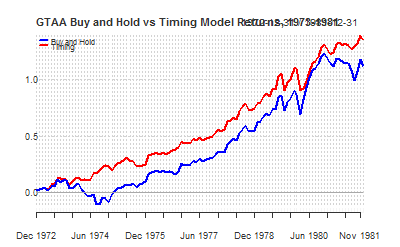

```r
#copies stats to clipboad for pasting into word/excel
write.table(stats, "clipboard", sep="\t", col.names=NA)
###gtaa chart b&h vs timing
Returns <- cbind.xts(AllAssets.xts$BuyandHold.ret,
                     AllAssets.xts$Timing.ret)[SubsetPeriod.Reporting]
colnames(Returns) <- c("Buy and Hold","Timing")
chart.CumReturns(Returns,
  #wealth.index = TRUE,
  main = "GTAA Buy and Hold vs Timing Model Returns, 1973-1981",
  colorset = c(4,2,3,5,6),legend.loc = "topleft",
  date.format = "%Y", ylab = "", ylog = TRUE)
```

[output not shown]

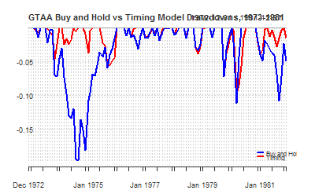

```r
chart.Drawdown(Returns,#[,-1], to exclude B&H
  main = "GTAA Buy and Hold vs Timing Model Drawdowns, 1973-1981",
  date.format = "%Y", colorset = c(4,2,3,5,6),
  ylab = "Drawdown", legend.loc = "bottomright", major.ticks = "years",  minor.ticks = FALSE)
```

```r
#### gtaa stats
TimeInMarket <- c(nrow(AllAssets.xts[SubsetPeriod.Reporting]),
                  sum(AllAssets.xts$Timing.signal[SubsetPeriod.Reporting]),
                  sum(AllAssets.xts$DelayedTiming.signal[SubsetPeriod.Reporting]))/nrow(AllAssets.xts[SubsetPeriod.Reporting])
FullStats <- rbind(Return.annualized(Returns,scale = 12)*FormatMultiplier,
                   StdDev.annualized(Returns,scale = 12)*FormatMultiplier,
                   skewness(Returns),
                   kurtosis(Returns),
                   100*c(Return.annualized(AllAssets.ret$CPI[SubsetPeriod.Reporting],scale = 12)),
                   TimeInMarket*FormatMultiplier,
                   apply(Returns, 2, function(x) length(x[x>0]))/nrow(Returns)*FormatMultiplier,
                   apply(Returns, 2, function(x) max(x, na.rm = TRUE))*FormatMultiplier,
                   apply(Returns, 2, function(x) min(x, na.rm = TRUE))*FormatMultiplier,
                   maxDrawdown(Returns,scale = 12,invert = FALSE)*FormatMultiplier,
                   -maxDrawdown(Returns,scale = 12,invert = FALSE)/Return.annualized(Returns,scale = 12),
                   SharpeRatio.annualized(Returns,Rf = AllAssets.ret$TBILLS[SubsetPeriod.Reporting]),
                   SortinoRatio(Returns, scale = 12), #what MAR?
                   CalmarRatio(Returns, scale = 12),
                   UlcerIndex(Returns)*FormatMultiplier)
colnames(FullStats) <- colnames(Returns)
rownames(FullStats) <- PerformanceMeasures
round(FullStats,2)
```

|  | Buy and Hold | Timing |
| --- | --- | --- |
| CAGR | 8.61 | 9.86 |
| Volatility | 10.79 | 8.14 |
| Skew | -0.33 | -0.80 |
| Kurtosis | 1.20 | 3.08 |
| Inflation CAGR | 9.23 | 9.23 |
| % in the Market | 100.00 | 68.07 |
| % positive Months | 60.55 | 69.72 |
| Best Month | 9.10 | 6.57 |
| Worst Month | -9.23 | -9.29 |
| Max Drawdown | -19.61 | -9.56 |

[output cut: 5 more lines]

```r
write.table(round(FullStats,4), "clipboard", sep="\t", col.names=NA)
SubsetPeriod.Reporting <- "1972-12-31::2016-12-31"
```

### Delayed Entry

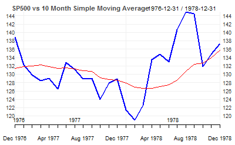

```r
SubsetPeriod.Reporting <- "1976-12-31::1978-12-31"
chart_Series(Cl(SP500),
  name = paste("SP500 vs 10 Month Simple Moving Average",sep = ""),
  theme=myChart_Theme,
  type = "line",
  subset = SubsetPeriod.Reporting,
  TA = 'add_SMA(n=SMAperiod, on=1, col="red")'
  )
```

[output not shown]

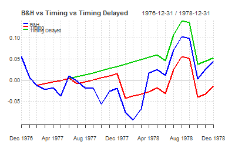

```r
Returns <- cbind.xts(AllAssets.xts$SP500.ret,
                     AllAssets.xts$SP500.10m.timingret,
                     AllAssets.xts$SP500.10m.timingret.delayed)[SubsetPeriod.Reporting]
colnames(Returns) <- c("B&H","Timing","Timing Delayed")
chart.CumReturns(Returns,
                 #wealth.index = TRUE,
                 main = "B&H vs Timing vs Timing Delayed",
                 colorset = c(4,2,3,5,6),legend.loc = "topleft",
                 date.format = "%Y", ylab = "", ylog = TRUE)
```

[output not shown]

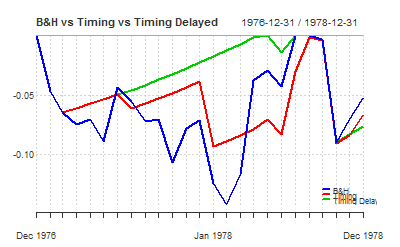

```r
chart.Drawdown(Returns,#[,-1], to exclude B&H
               main = "B&H vs Timing vs Timing Delayed",
               date.format = "%Y", colorset = c(4,2,3,5,6),
               ylab = "Drawdown", legend.loc = "bottomright", major.ticks = "years",  minor.ticks = FALSE)
```

```r
TimeInMarket <- c(nrow(AllAssets.xts[SubsetPeriod.Reporting]),
                  sum(AllAssets.xts$SP500.10m.signal[SubsetPeriod.Reporting]),
                  sum(AllAssets.xts$SP500.10m.signal.delayed[SubsetPeriod.Reporting]))/nrow(AllAssets.xts[SubsetPeriod.Reporting])
FullStats <- rbind(Return.annualized(Returns,scale = 12)*FormatMultiplier,
                   StdDev.annualized(Returns,scale = 12)*FormatMultiplier,
                   skewness(Returns),
                   kurtosis(Returns),
                   100*c(Return.annualized(AllAssets.ret$CPI[SubsetPeriod.Reporting],scale = 12)),
                   TimeInMarket*FormatMultiplier,
                   apply(Returns, 2, function(x) length(x[x>0]))/nrow(Returns)*FormatMultiplier,
                   apply(Returns, 2, function(x) max(x, na.rm = TRUE))*FormatMultiplier,
                   apply(Returns, 2, function(x) min(x, na.rm = TRUE))*FormatMultiplier,
                   maxDrawdown(Returns,scale = 12,invert = FALSE)*FormatMultiplier,
                   -maxDrawdown(Returns,scale = 12,invert = FALSE)/Return.annualized(Returns,scale = 12),
                   SharpeRatio.annualized(Returns,Rf = AllAssets.ret$TBILLS[SubsetPeriod.Reporting]),
                   #SharpeRatio.annualized(Returns,Rf = Rf.ret$TBILLYIELDS.Close),
                   SortinoRatio(Returns, scale = 12), #what MAR?
                   CalmarRatio(Returns, scale = 12),
                   UlcerIndex(Returns)*FormatMultiplier)
colnames(FullStats) <- colnames(Returns)

rownames(FullStats) <- PerformanceMeasures
round(FullStats,2)
```

|  | B&H | Timing | Timing Delayed |
| --- | --- | --- | --- |
| CAGR | 2.13 | -0.67 | 2.48 |
| Volatility | 13.66 | 10.51 | 9.52 |
| Skew | 0.00 | -0.84 | -1.03 |
| Kurtosis | 0.09 | 1.93 | 3.81 |
| Inflation CAGR | 7.77 | 7.77 | 7.77 |
| % in the Market | 100.00 | 48.00 | 32.00 |
| % positive Months | 52.00 | 72.00 | 80.00 |
| Best Month | 9.02 | 5.84 | 5.84 |
| Worst Month | -8.72 | -8.72 | -8.72 |
| Max Drawdown | -14.26 | -9.39 | -9.01 |

[output cut: 5 more lines]

```r
write.table(round(FullStats,4), "clipboard", sep="\t", col.names=NA)
SubsetPeriod.Reporting <- "1972-12-31::2016-12-31"
```

### Bands - S&P

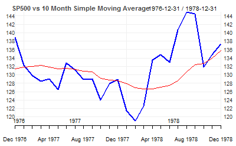

```r
#SubsetPeriod.Reporting <- "1972-12-31::2016-12-31"
SubsetPeriod.Reporting <- "1976-12-31::1978-12-31"
chart_Series(Cl(SP500),
  name = paste("SP500 vs 10 Month Simple Moving Average",sep = ""),
  theme=myChart_Theme,
  type = "line",
  subset = SubsetPeriod.Reporting,
  TA = 'add_SMA(n=SMAperiod, on=1, col="red")'
  )
```

[output not shown]

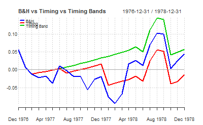

```r
Returns <- cbind.xts(AllAssets.xts$SP500.ret,
                     AllAssets.xts$SP500.10m.timingret,
                     AllAssets.xts$SP500.10m.timingret.band)[SubsetPeriod.Reporting]
colnames(Returns) <- c("B&H","Timing","Timing Band")
chart.CumReturns(Returns,
                 #wealth.index = TRUE,
                 main = "B&H vs Timing vs Timing Bands",
                 colorset = c(4,2,3,5,6),legend.loc = "topleft",
                 date.format = "%Y", ylab = "", ylog = TRUE)
```

[output not shown]

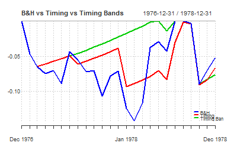

```r
chart.Drawdown(Returns,#[,-1], to exclude B&H
               main = "B&H vs Timing vs Timing Bands",
               date.format = "%Y", colorset = c(4,2,3,5,6),
               ylab = "Drawdown", legend.loc = "bottomright", major.ticks = "years",  minor.ticks = FALSE)
```

```r
TimeInMarket <- c(nrow(AllAssets.xts[SubsetPeriod.Reporting]),
                  sum(AllAssets.xts$SP500.10m.signal[SubsetPeriod.Reporting]),
                  sum(AllAssets.xts$SP500.10m.signal.band[SubsetPeriod.Reporting]))/nrow(AllAssets.xts[SubsetPeriod.Reporting])
FullStats <- rbind(Return.annualized(Returns,scale = 12)*FormatMultiplier,
                   StdDev.annualized(Returns,scale = 12)*FormatMultiplier,
                   skewness(Returns),
                   kurtosis(Returns),
                   100*c(Return.annualized(AllAssets.ret$CPI[SubsetPeriod.Reporting],scale = 12)),
                   TimeInMarket*FormatMultiplier,
                   apply(Returns, 2, function(x) length(x[x>0]))/nrow(Returns)*FormatMultiplier,
                   apply(Returns, 2, function(x) max(x, na.rm = TRUE))*FormatMultiplier,
                   apply(Returns, 2, function(x) min(x, na.rm = TRUE))*FormatMultiplier,
                   maxDrawdown(Returns,scale = 12,invert = FALSE)*FormatMultiplier,
                   -maxDrawdown(Returns,scale = 12,invert = FALSE)/Return.annualized(Returns,scale = 12),
                   SharpeRatio.annualized(Returns,Rf = AllAssets.ret$TBILLS[SubsetPeriod.Reporting]),
                   #SharpeRatio.annualized(Returns,Rf = Rf.ret$TBILLYIELDS.Close),
                   SortinoRatio(Returns, scale = 12), #what MAR?
                   CalmarRatio(Returns, scale = 12),
                   UlcerIndex(Returns)*FormatMultiplier)
colnames(FullStats) <- colnames(Returns)

rownames(FullStats) <- PerformanceMeasures
round(FullStats,2)
```

|  | B&H | Timing | Timing Band |
| --- | --- | --- | --- |
| CAGR | 2.13 | -0.67 | 2.67 |
| Volatility | 13.66 | 10.51 | 9.53 |
| Skew | 0.00 | -0.84 | -1.05 |
| Kurtosis | 0.09 | 1.93 | 3.80 |
| Inflation CAGR | 7.77 | 7.77 | 7.77 |
| % in the Market | 100.00 | 48.00 | 36.00 |
| % positive Months | 52.00 | 72.00 | 80.00 |
| Best Month | 9.02 | 5.84 | 5.84 |
| Worst Month | -8.72 | -8.72 | -8.72 |
| Max Drawdown | -14.26 | -9.39 | -9.01 |

[output cut: 5 more lines]

```r
write.table(round(FullStats,4), "clipboard", sep="\t", col.names=NA)
SubsetPeriod.Reporting <- "1972-12-31::2016-12-31"
```

[output not shown]

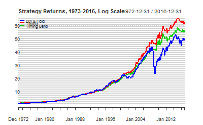

```r
SubsetPeriod.Reporting <- "1972-12-31::2016-12-31"
Returns <- cbind.xts(AllAssets.xts$BuyandHold.ret,
                     AllAssets.xts$Timing.ret,
                     AllAssets.xts$BandTiming.ret)[SubsetPeriod.Reporting]
colnames(Returns) <- c("Buy & Hold","Timing","Timing Band")
chart.CumReturns(Returns, wealth.index = TRUE,
  main = "Strategy Returns, 1973-2016, Log Scale",
  colorset = c(4,2,3,5,6),legend.loc = "topleft",
  date.format = "%Y", ylab = "", ylog = TRUE)
```

[output not shown]

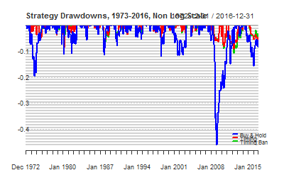

```r
chart.Drawdown(Returns,#[,-1], to exclude B&H
  main = "Strategy Drawdowns, 1973-2016, Non Log Scale",
  date.format = "%Y", colorset = c(4,2,3,5,6),
  ylab = "Drawdown", legend.loc = "bottomright", major.ticks = "years",  minor.ticks = FALSE)
```

```r
TimeInMarket <- c(nrow(AllAssets.xts[SubsetPeriod.Reporting]),
                  sum(AllAssets.xts$Timing.signal[SubsetPeriod.Reporting]),
                  sum(AllAssets.xts$BandTiming.signal[SubsetPeriod.Reporting]))/nrow(AllAssets.xts[SubsetPeriod.Reporting])
FullStats <- rbind(Return.annualized(Returns,scale = 12)*FormatMultiplier,
                   StdDev.annualized(Returns,scale = 12)*FormatMultiplier,
                   skewness(Returns),
                   kurtosis(Returns),
                   100*c(Return.annualized(AllAssets.ret$CPI[SubsetPeriod.Reporting],scale = 12)),
                   TimeInMarket*FormatMultiplier,
                   apply(Returns, 2, function(x) length(x[x>0]))/nrow(Returns)*FormatMultiplier,
                   apply(Returns, 2, function(x) max(x, na.rm = TRUE))*FormatMultiplier,
                   apply(Returns, 2, function(x) min(x, na.rm = TRUE))*FormatMultiplier,
                   maxDrawdown(Returns,scale = 12,invert = FALSE)*FormatMultiplier,
                   -maxDrawdown(Returns,scale = 12,invert = FALSE)/Return.annualized(Returns,scale = 12),
                   SharpeRatio.annualized(Returns,Rf = AllAssets.ret$TBILLS[SubsetPeriod.Reporting]),
                   SortinoRatio(Returns, scale = 12), #what MAR?
                   CalmarRatio(Returns, scale = 12),
                   UlcerIndex(Returns)*FormatMultiplier)
colnames(FullStats) <- colnames(Returns)
rownames(FullStats) <- PerformanceMeasures
round(FullStats,2)
```

|  | Buy & Hold | Timing | Timing Band |
| --- | --- | --- | --- |
| CAGR | 9.29 | 9.84 | 9.57 |
| Volatility | 10.08 | 6.87 | 6.65 |
| Skew | -1.02 | -0.48 | -0.60 |
| Kurtosis | 5.06 | 2.35 | 2.89 |
| Inflation CAGR | 9.23 | 9.23 | 9.23 |
| % in the Market | 100.00 | 70.81 | 64.91 |
| % positive Months | 65.60 | 70.51 | 71.83 |
| Best Month | 9.22 | 6.58 | 6.58 |
| Worst Month | -19.34 | -9.29 | -9.29 |
| Max Drawdown | -46.10 | -9.56 | -10.82 |

[output cut: 5 more lines]

```r
write.table(round(FullStats,4), "clipboard", sep="\t", col.names=NA)
```

#### Example of benefit of averaging timing signals

```r
#for calculating the sharpe ratio later
Rf.ret <- Return.calculate(TBILLYIELDS)[-1,]
Rf.ret <- Rf.ret[SubsetPeriod.Reporting]
#Get Returns
Returns <- cbind.xts(AllAssets.xts$EAFE.ret,
                     AllAssets.xts$EAFE.2m.timingret,
                     AllAssets.xts$EAFE.5m.timingret,
                     AllAssets.xts$EAFE.10m.timingret,
                     AllAssets.xts$EAFE.avg.timingret)[SubsetPeriod.Reporting]
#Time in market
TimeInMarket <- c(nrow(AllAssets.xts[SubsetPeriod.Reporting]),
  sum(AllAssets.xts$EAFE.2m.signal[SubsetPeriod.Reporting]),
  sum(AllAssets.xts$EAFE.5m.signal[SubsetPeriod.Reporting]),
  sum(AllAssets.xts$EAFE.10m.signal[SubsetPeriod.Reporting]),
  sum(AllAssets.xts$EAFE.avg.signal[SubsetPeriod.Reporting]))/nrow(AllAssets.xts[SubsetPeriod.Reporting])
FormatMultiplier <- 100
FullStats <- rbind(Return.annualized(Returns,scale = 12)*FormatMultiplier,
                   StdDev.annualized(Returns,scale = 12)*FormatMultiplier,
                   skewness(Returns),
                   kurtosis(Returns),
                   100*c(Return.annualized(AllAssets.ret$CPI[SubsetPeriod.Reporting],scale = 12)),
                   TimeInMarket*FormatMultiplier,
                   apply(Returns, 2, function(x) length(x[x>0]))/nrow(Returns)*FormatMultiplier,
                   apply(Returns, 2, function(x) max(x, na.rm = TRUE))*FormatMultiplier,
                   apply(Returns, 2, function(x) min(x, na.rm = TRUE))*FormatMultiplier,
                   maxDrawdown(Returns,scale = 12,invert = FALSE)*FormatMultiplier,
                   -maxDrawdown(Returns,scale = 12,invert = FALSE)/Return.annualized(Returns,scale = 12),
                   SharpeRatio.annualized(Returns,Rf = Rf.ret$TBILLYIELDS.Close),
                   SortinoRatio(Returns, scale = 12), #what MAR?
                   CalmarRatio(Returns, scale = 12),
                   UlcerIndex(Returns)*FormatMultiplier)
colnames(FullStats) <- c("B&H","2M Timing","5M Timing","10M Timing","Avg Timing")
rownames(FullStats) <- c("CAGR","Volatility","Skew","Kurtosis","Inflation CAGR","% in the Market","% positive Months","Best Month","Worst Month","Max Drawdown","Max Drawdown / CAGR",paste("Sharpe Ratio (",round(100*Return.annualized(Return.calculate(TBILLS)[SubsetPeriod.Reporting]),2),"%)", sep = ""),"Sortino Ratio","MAR Ratio","Ulcer Index")
round(FullStats,2)
```

|  | B&H | 2M Timing | 5M Timing | 10M Timing | Avg Timing |
| --- | --- | --- | --- | --- | --- |
| CAGR | 8.81 | 9.77 | 9.06 | 9.31 | 9.51 |
| Volatility | 17.20 | 11.91 | 12.38 | 12.37 | 11.24 |
| Skew | -0.29 | 0.18 | -0.08 | -0.23 | 0.16 |
| Kurtosis | 1.02 | 2.99 | 2.45 | 2.26 | 2.09 |
| Inflation CAGR | 9.23 | 9.23 | 9.23 | 9.23 | 9.23 |
| % in the Market | 100.00 | 59.17 | 63.71 | 69.19 | 64.02 |
| % positive Months | 59.17 | 76.37 | 74.29 | 72.97 | 69.19 |
| Best Month | 17.87 | 14.09 | 14.09 | 14.09 | 14.09 |
| Worst Month | -20.17 | -14.38 | -13.99 | -13.99 | -12.37 |
| Max Drawdown | -56.40 | -25.92 | -28.75 | -25.49 | -25.12 |

[output cut: 5 more lines]

```r
write.table(round(FullStats,4), "clipboard", sep="\t", col.names=NA)
#how do i get a distribution chart to check skew/kurtosis
```

### compare delayed to normal to see benefits of avoiding whipsaws

```r
#for calculating the sharpe ratio later
Rf.ret <- Return.calculate(TBILLYIELDS)[-1,]
Rf.ret <- Rf.ret[SubsetPeriod.Reporting]
Returns <- cbind.xts(AllAssets.xts$SP500.10m.timingret,
                     AllAssets.xts$SP500.10m.timingret.delayed)[SubsetPeriod.Reporting]
#Time in market
TimeInMarket <- c(sum(AllAssets.xts$SP500.10m.signal[SubsetPeriod.Reporting]),
  sum(AllAssets.xts$SP500.10m.signal.delayed[SubsetPeriod.Reporting]))/nrow(AllAssets.xts[SubsetPeriod.Reporting])

FormatMultiplier <- 100
FullStats <- rbind(Return.annualized(Returns,scale = 12)*FormatMultiplier,
                   StdDev.annualized(Returns,scale = 12)*FormatMultiplier,
                   skewness(Returns),
                   kurtosis(Returns),
                   100*c(Return.annualized(AllAssets.ret$CPI[SubsetPeriod.Reporting],scale = 12)),
                   TimeInMarket*FormatMultiplier,
                   apply(Returns, 2, function(x) length(x[x>0]))/nrow(Returns)*FormatMultiplier,
                   apply(Returns, 2, function(x) max(x, na.rm = TRUE))*FormatMultiplier,
                   apply(Returns, 2, function(x) min(x, na.rm = TRUE))*FormatMultiplier,
                   maxDrawdown(Returns,scale = 12,invert = FALSE)*FormatMultiplier,
                   -maxDrawdown(Returns,scale = 12,invert = FALSE)/Return.annualized(Returns,scale = 12),
                   SharpeRatio.annualized(Returns,Rf = Rf.ret$TBILLYIELDS.Close),
                   SortinoRatio(Returns, scale = 12), #what MAR?
                   CalmarRatio(Returns, scale = 12),
                   UlcerIndex(Returns)*FormatMultiplier)
colnames(FullStats) <- c("Timing","Delayed Timing")
rownames(FullStats) <- c("CAGR","Volatility","Skew","Kurtosis","Inflation CAGR","% in the Market","% positive Months","Best Month","Worst Month","Max Drawdown","Max Drawdown / CAGR",paste("Sharpe Ratio (",round(100*Return.annualized(Return.calculate(TBILLS)[SubsetPeriod.Reporting]),2),"%)", sep = ""),"Sortino Ratio","MAR Ratio","Ulcer Index")
round(FullStats,2)
```

|  | Timing | Delayed Timing |
| --- | --- | --- |
| CAGR | 10.35 | 10.03 |
| Volatility | 11.61 | 11.22 |
| Skew | -0.68 | -0.71 |
| Kurtosis | 5.19 | 6.13 |
| Inflation CAGR | 9.23 | 9.23 |
| % in the Market | 74.67 | 69.19 |
| % positive Months | 73.35 | 75.24 |
| Best Month | 13.47 | 13.47 |
| Worst Month | -21.54 | -21.54 |
| Max Drawdown | -23.29 | -23.26 |

[output cut: 5 more lines]

```r
write.table(round(FullStats,4), "clipboard", sep="\t", col.names=NA)
#how do i get a distribution chart to check skew/kurtosis
```

```r
chart.RollingPerformance(Returns$"10m Timing Delayed"-Returns$"10m Timing",
                         width = 3,
                         main = "Rolling Perf"
                         )
```

[output not shown]

```r
chart_Series(Cl(US10YR),
  name = paste("US10YR vs 10 Month Simple Moving Average",sep = ""),
  theme=myChart_Theme,
  type = "line",
  subset = "1983::1986-06",
  TA = 'add_SMA(n=SMAperiod, on=1, col="red")'
  )
```

[output not shown]

so better sharpe? [confirm calc method/fix interest rate… should i calc manually?] and less maxdd whats kurtosis, information ratio, skew. ask what metrics rad, mb and emyln use… run on longer dater in asset allocation ratios

last 12 months, 3 years, etc returns

rolling returns

to do:

- how to calculate dailyreturns with NA
- check returns make sense - effect of zar?
- compare to US / JPY
- create RF to get 2002 in

To do: SA assets Daily drawdowns monthly returns table Relative performance / rolling perofrmance / alpha 10 worst periods / 10 best periods do different averages improve SA - check robustness of averages….